# HW 3 - Synonym Detection In Spark

**`MIDS w261: Machine Learning at Scale | UC Berkeley School of Information | Spring 2023`**

You made it through Hadoop! 👏 This will be your first assignment working in Spark so that's 🔥. In the last homework assignment you performed Naive Bayes to classify documents as 'ham' or 'spam.' In doing so, we relied on the implicit assumption that the list of words in a document can tell us something about the nature of that document's content. We'll rely on a similar intuition this week: the idea that, if we analyze a large enough corpus of text, the list of words that appear in small window before or after a vocabulary term can tell us something about that term's meaning. This is similar to the intuition behind the word2vec algorithm. For HW3, you'll perform Synonym Detection by repurposing an algorithm commonly used in Natural Language Processing to perform document similarity analysis. In doing so you'll also become familiar with important datatypes for efficiently processing sparse vectors and a number of set similarity metrics (e.g. Cosine, Jaccard, Dice). By the end of this homework you should be able to:

- ... **define** the terms `one-hot encoding`, `co-occurrence matrix`, `stripe`, `inverted index`, `postings`, and `basis vocabulary` in the context of both synonym detection and document similarity analysis.
- ... **explain** the reasoning behind using a word stripe to compare word meanings.
- ... **identify** what makes set-similarity calculations computationally challenging.
- ... **implement** stateless algorithms in Spark to build stripes, inverted index and compute similarity metrics.
- ... **identify** when it makes sense to take a stripe approach and when to use pairs
- ... **apply** appropriate metrics to assess the performance of your synonym detection algorithm.

As always, your work will be graded both on the correctness of your output and on the clarity and design of your code.

Please use the Digital Campus quiz along with the hw3_workbook.ipynb. Importantly, you will no longer be working in `Local Disk/media`, but in `GCS` using your personal storage bucket. Your assignment is located at `GCS/Assignments/HW3/hw3_Workbook.ipynb`.In fact, assignments 3, 4, and 5 will all utilize storage buckets rather than `Local Disk/media`.

You will need to complete the notebook tasks in your notebook before filling them in Digital Campus and submitting. Once again, we recommend that you complete your responses in the notebook and then copy them to Digital Campus when you are ready to submit the assignment.

**RECOMMENDED READING FOR HW3**:  
Your reading assignment for weeks 4 and 5 were fairly heavy and you may have glossed over the papers on dimension independent similarity metrics by [Zadeh et al](http://stanford.edu/~rezab/papers/disco.pdf) and pairwise document similarity by [Elsayed et al](https://terpconnect.umd.edu/~oard/pdf/acl08elsayed2.pdf). If you haven't already, this would be a good time to review those readings, especially when it comes to the similarity formulas -- they are directly relevant to this assignment.

DITP Chapter 4 - Inverted Indexing for Text Retrieval. While this text is specific to Hadoop, the Map/Reduce concepts still apply.

## Notebook Set-Up

Before starting your homework run review the following and run the code cells to confirm your setup.

### Data and HW output vs notebook Locations: private data bucket versus dataproc staging bucket

When you create a DataProc cluster, HDFS is used as the default filesystem. In this course, we override this behavior by setting the defaultFS as a Cloud Storage bucket. The benefits of using Cloud Storage buckets are that your job results get to persist beyond the lifetime of the cluster (and btw latency on these cloud buckets is super low).

In this HW, you use your personal cloud bucket (and folders on them), known as DATA_BUCKET, as:

- input and output for the Spark Apps that you will develop as part of your submission.
- you will save your jupyter notebooks and data on your personal cloud bucket also!

The datasets for this homework are preloaded into your `private Data Bucket` on Google Cloud. Recall that you created a private data bucket during the first week of semester. You may have called it w261-. Jimi's bucket name is `w261-jgs`. To facilitate ease of access, we have set up location variables for the course-related data buckets. Your private data bucket can be accessed via:

- ```
  import os
    DATA_BUCKET = os.getenv('DATA_BUCKET','')[:-1] # our private storage bucket location
  ```

This DATA_BUCKET will be used for hosting the input data for this assignment and also to store output from your HW Assignment apps. Associated with each DataProc cluster is a persistant storage bucket that we refer to as the DataProc Staging Bucket. You will be using this staging bucket to store notebooks and other files associated with your HW assignments, and live sessions. The location of the staging bucket is made available via `os.getenv("STAGING_BUCKET")`. Since this bucket is persistent, we will no longer need to snapshot your student workspaces.

For more background on Dataproc staging buckets please see:

- https://cloud.google.com/dataproc/docs/concepts/configuring-clusters/staging-bucket

```python
# Access your personal data bucket and see whats there
# (RUN THIS CELL AS IS)
import os
DATA_BUCKET = os.getenv('DATA_BUCKET','')[:-1] # our private storage bucket location
HW3_FOLDER = f"{DATA_BUCKET}/notebooks/jupyter/Assignments/HW3"
print(f"Personal Data bucket:  {DATA_BUCKET}")
!gsutil ls -lh  {HW3_FOLDER}  #lets have a look the HW3 folder on our private storage bucket
```

```
Personal Data bucket:  gs://w261-hr
  2.17 MiB  2023-06-19T08:25:01Z  gs://w261-hr/notebooks/jupyter/Assignments/HW3/hw3_Workbook-HR.ipynb
 108.7 KiB  2023-05-20T20:20:22Z  gs://w261-hr/notebooks/jupyter/Assignments/HW3/hw3_Workbook.ipynb
  1.19 KiB  2023-05-20T20:20:22Z  gs://w261-hr/notebooks/jupyter/Assignments/HW3/readme.md
     145 B  2023-06-18T22:55:28Z  gs://w261-hr/notebooks/jupyter/Assignments/HW3/sample_docs.txt
489.21 KiB  2023-05-20T20:20:22Z  gs://w261-hr/notebooks/jupyter/Assignments/HW3/scaling-up-similarity-search.pdf
     494 B  2023-06-18T23:24:20Z  gs://w261-hr/notebooks/jupyter/Assignments/HW3/systems_test.txt
                                 gs://w261-hr/notebooks/jupyter/Assignments/HW3/data/
                                 gs://w261-hr/notebooks/jupyter/Assignments/HW3/output/
                                 gs://w261-hr/notebooks/jupyter/Assignments/HW3/stripes/
TOTAL: 6 objects, 2890276 bytes (2.76 MiB)
```

```python
import re
import ast
import time
import itertools
import numpy as np
import pandas as pd
import matplotlib.pyplot as plt
```

```python
# to shutdown Spark. (RUN THIS CELL AS IS)
# if Spark is not running no problem
# if Spark is running no problem also it will be shutdown
#

try:
    spark
    print(f"{sc.master} appName: {sc.appName}")
    spark.sparkContext.stop()
    del spark; del sc
    print(f"Just Shutdown Spark.")
except NameError:
    print("Spark is NOT currently running")
```

```
Spark is NOT currently running
```

```python
# start Spark Session (RUN THIS CELL AS IS)
#Step A: Start Spark by running the following cell

from pyspark.sql import SparkSession

try:
    spark
    print("Spark is already running")
    print(f"{sc.master} appName: {sc.appName}")
except NameError:
    print('starting Spark')
    app_name = 'hw3_notebook'
    master = "local[*]"
    spark = SparkSession\
            .builder\
            .appName(app_name)\
            .master(master)\
            .getOrCreate()
sc = spark.sparkContext

# Don't worry about messages shown below
```

```
starting Spark
:: loading settings :: url = jar:file:/usr/lib/spark/jars/ivy-2.5.1.jar!/org/apache/ivy/core/settings/ivysettings.xml
```

[output not shown]

## OPTIONAL: Setup Spark UI (jobs and stages)

Web UI (aka Application UI or webUI or Spark UI) is the web interface of a running Spark application to monitor and inspect Spark job executions in a web browser. The following is a screenshot of the Spark UI. Feel free to skip this section.

Note: these steps need to be repeated if the cloud shell is restarted

[figure not shown]

Getting access to Spark UI, you will need to create a tunnel from DataProc via the CloudShell. Please follow all steps depicted below :

- Launch Spark first (as described above)!
- The run the following command (make sure your specify the correct zone!)

```
gcloud compute ssh w261-m --zone us-central1-a --ssh-flag "-L 8080:localhost:4040"
```

```python
import os
ZONE = os.getenv('ZONE','') # zone where the DataProc cluster is running
print(ZONE)
print("Copy the following command (and swap out the ZONE for your cluster zone) to cloud shell\n"+
      "and run as shown in the screenshot below. \n"+
      "And click on the PREVIEW ON PORT 8080 menu option in the web preview menu (look for the icon <>).\n\n")
f'   gcloud compute ssh w261-m --zone {ZONE} --ssh-flag "-L 8080:localhost:4040"    '
```

```python
# gcloud compute ssh w261-m --zone us-central1-a --ssh-flag "-L 8080:localhost:4040"
```

[figure not shown]

```python
# get Spark Session info (RUN THIS CELL AS IS)
spark #NOTE the Spark UI link provided below as output from this command does not work. See next section on how to get that working.
```

**SparkSession - hive**

**SparkContext**

[Spark UI](http://w261-m.c.w261-student-387320.internal:4040)

**Version**

`v3.1.3`

**Master**

`local[*]`

**AppName**

`hw3_notebook`

# ✅ Question 1: Spark Basics.

In your readings and live session demos for weeks 4 and 5 you got a crash course in working with Spark. We also talked about how Spark RDDs fit into the broader picture of distributed algorithm design. The questions below cover key points from these discussions. Answer each one very briefly - 2 to 3 sentences.

### Q1 Tasks:

- **a) Matching on Digital Campus:** Match each statement to the answer choice that best fits the statement about Hadoop and Spark (see Digital Campus).

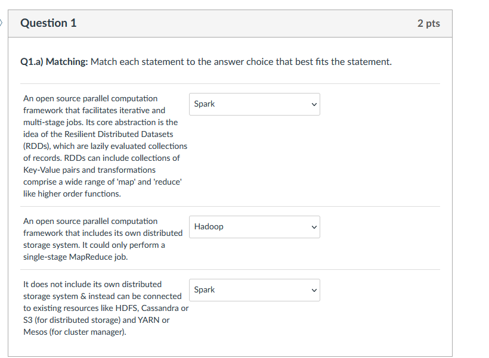

- **b) Multiple Answer on Digital Campus:** Spark generally follows the principles of statelessness (a.k.a. functional programming). In what ways does the framework allow the programmer to depart from this principle? (Select 2 answers)

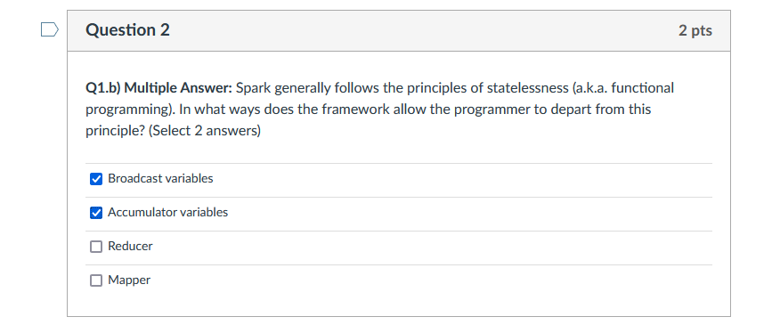

- **c) Short Response on Digital Campus:** In the context of Spark what is a 'DAG' and how does it relate to the difference between an 'action' and a 'transformation'? Why is it useful to pay attention to the DAG that underlies your Spark implementation?

> A DAG is a Directed Acyclic Graph, which in the context of Spark are used to structure and optimize the execution plan based on the actions and transformations specified in user code. The DAG in Spark is a set of vertices and edges, where vertices represent the RDDs and the edges represent the operation to be applied on RDD. On the calling of Action, the created DAG submits to DAG Scheduler which further splits the graph into the stages of the task.

> *With info from https://data-flair.training/blogs/dag-in-apache-spark/https://data-flair.training/blogs/dag-in-apache-spark/*

# ✅ Question 2: Similarity Metrics

## Q2(a) Cosine Similarity

In data analysis, cosine similarity is a measure of similarity between two sequences of numbers. For defining it, the sequences are viewed as vectors in an inner product space, and the cosine similarity is defined as the cosine of the angle between them, that is, the dot product of the vectors divided by the product of their lengths. More formally, cosine similarity between two non-zero vectors A and B builds on the Euclidean dot product formula and is defined as follows:

$${\text{cosine similarity}}=S_{COS}(A,B):=\cos(\theta )={\mathbf {A} \cdot \mathbf {B} \over \|\mathbf {A} \|\|\mathbf {B} \|}= {\frac {\sum \limits _{i=1}^{n}{A_{i}B_{i}}}{\sqrt{\sum_{i=1}^{n}{A_{i}^{2}}} \cdot \sqrt{\sum_{i=1}^{n}{B_{i}^{2}}}}}$$

Where $A_i$ and $B_i$ are components of vector A and B in space respectively. For example, give A=[1,2], and B=[3,4],

$$S_{COS}(A=[1,2],B=[3,4]):=\cos(\theta)={{\mathbf{[1,2]}\cdot\mathbf{[3,4]}\over \|\mathbf{[1,2]}\|\|\mathbf{[3,4]}\|}}={\frac{11}{2.236 \cdot 5.0}}=0.984$$

Looking more closely at cosine similarity:

- It follows that the cosine similarity does not depend on the magnitudes of the vectors, but only on their angle.
- The cosine similarity always belongs to the interval [-1,1].
- For example, two proportional vectors have a cosine similarity of 1, two orthogonal vectors have a similarity of 0, and two opposite vectors have a similarity of -1.
- The cosine similarity is particularly used in positive space, where the outcome is neatly bounded in [0,1].

With this as background, please complete the following code to calculate the cosine similarity between two generated vectors A and B, and report the similarity to three decimal places of these two vectors.

```python
# part a
import numpy as np
# The points below have been selected to demonstrate the case for Cosine similarity

# Cosine similarity
np.random.seed(2)
A = np.random.randint(low=0, high=10, size=10, dtype=int)
B = np.random.randint(low=0, high=10, size=10, dtype=int)
print(f"A: {A}")
print(f"B: {B}")
print(f"A.B: {np.dot(A, B)}")
print(f"A.B: {A @ B}")
#Cosine similarity
cosine_sim = A @ B / float(np.linalg.norm(A)*np.linalg.norm(B))
print(f"cosine_sim(A, B): {cosine_sim:.3}")
```

```
A: [8 8 6 2 8 7 2 1 5 4]
B: [4 5 7 3 6 4 3 7 6 1]
A.B: 243
A.B: 243
cosine_sim(A, B): 0.857
```

## Q2(b) Jaccard Similarity

Jaccard similarity is another measure of similarity between two sequences of numbers. It is defined by the intersection divided by the union of two sets of numbers. Between two non-zero sets $\mathbf {A}$ and $\mathbf {B}$, jaccard similarity can be defined by: $${\text{jaccard similarity}}={|\mathbf {A} \cap \mathbf {B}| \over |\mathbf {A} \cup \mathbf {B}| } = {|\mathbf {A} \cap \mathbf {B}| \over |\mathbf {A}| +|\mathbf {B}| - |\mathbf {A} \cap \mathbf {B}|}$$

As a result:

- Jaccard similarity is the ratio of shared elements to unshared elements. I.e., Jaccard Similarity = (number of non-zero elements in both sets) / (number non-zero elements in either set)
- The Jaccard similarity always belongs to the interval [0,1].

With this as background, please complete the following code to calculate the Jaccard similarity between two generated vectors A and B, and report similarity to three decimal places.

```python
# part b
import numpy as np
# The points below have been selected to demonstrate the case for Jaccard similarity
# Jaccard similarity
np.random.seed(2)
A = np.random.randint(low=0, high=2, size=10, dtype=int)
B = np.random.randint(low=0, high=2, size=10, dtype=int)
print(f"A: {A}")
print(f"B: {B}")
print(f"A intersection B: {np.count_nonzero(np.logical_and(A, B))}")
jaccard_sim = np.count_nonzero(np.logical_and(A, B)) / np.count_nonzero(np.logical_or(A,B))  # hint: np.logical_or
print(f"jaccard_sim(A, B): {jaccard_sim:.3}")
```

```
A: [0 1 1 0 0 1 0 1 0 1]
B: [0 1 1 1 1 1 1 1 0 0]
A intersection B: 4
jaccard_sim(A, B): 0.5
```

## Q2(c) Overlap Similarity

The overlap coefficient is another measure of similarity between two sequences of numbers. It measures the overlap between two finite sets by using the size of the intersection divided by the smaller of the size of the two sets. Between two non-zero sets $A$ and $B$, It can be defined by:

$${\displaystyle \text{overlap coefficient}={\frac {|A\cap B|}{\min(|A|,|B|)}}}$$

As a result,

- In comparing two documents, overlap coefficient can be thought of as the percent of words in the document with fewer unique words that are also in the other document.
- If set A is a subset of B or the converse, then the overlap coefficient is equal to 1.

With this as background, please complete the following code to calculate the overlap metric between two generated vectors A and B, and report similarity to three decimal places.

```python
# part c
import numpy as np
# The points below have been selected to demonstrate the case for Overlap similarity
# Overlap similarity
np.random.seed(2)
A = np.random.randint(low=0, high=2, size=10, dtype=int)
B = np.random.randint(low=0, high=2, size=10, dtype=int)
print(f"A: {A}")
print(f"B: {B}")
print(f"A intersection B: {np.count_nonzero(np.logical_and(A, B))}")
overlap_sim = np.count_nonzero(np.logical_and(A, B)) /np.array([len(A), len(B)]).min()  # hint: min length
print(f"overlap_sim(A, B): {overlap_sim:.3}")
```

```
A: [0 1 1 0 0 1 0 1 0 1]
B: [0 1 1 1 1 1 1 1 0 0]
A intersection B: 4
overlap_sim(A, B): 0.4
```

## Q2(d) Dice Similarity

Dice similarity is another measure of similarity between two sequences of numbers. The metric equals twice the number of elements common to both sets divided by the sum of the number of elements in each set. Between two non-zero sets A and B, dice similarity can be defined by:

$${\displaystyle \text{dice coefficient}={\frac {2|A\cap B|}{|A|+|B|}}}$$

As a result,

- In comparing two documents, dice coefficient represents the shared word rate across both documents.

With this as background, please complete the following code to calculate the Dice similarity between two generated vectors A and B, and report similarity to three decimal places.

```python
# part d
import numpy as np
# The points below have been selected to demonstrate the case for Dice similarity
# Dice similarity
np.random.seed(2)
A = np.random.randint(low=0, high=2, size=10, dtype=int)
B = np.random.randint(low=0, high=2, size=10, dtype=int)
print(f"A: {A}")
print(f"B: {B}")
print(f"A intersection B: {np.count_nonzero(np.logical_and(A, B))}")
dice_sim = 2*np.count_nonzero(np.logical_and(A, B)) / float(len(A) + len(B))  # hint: total non zero elements between vectors
print(f"dice_sim(A, B): {dice_sim:.3}")
```

```
A: [0 1 1 0 0 1 0 1 0 1]
B: [0 1 1 1 1 1 1 1 0 0]
A intersection B: 4
dice_sim(A, B): 0.4
```

# ✅ Question 3: Synonym Detection Strategy

In the Synonym Detection task we want to compare the meaning of words, not documents. For clarity, lets call the words whose meaning we want to compare `terms`. If only we had a 'meaning document' (or an embedding vector) for each `term` then we could easily use the document similarity strategy from Question 2 to figure out which `terms` have similar meaning (i.e. are 'synonyms'). Of course in order for that to work we'd have to reasonably believe that the words in these 'meaning documents' really do reflect the meaning of the `term`. For a good analysis we'd also need these 'meaning documents' to be fairly long -- the one or two sentence dictionary definition of a term isn't going to provide enough signal to distinguish between thousands and thousands of `term` meanings. In another way, the length of an embedding vector has to be big enough to represent the `term`.

This is where the idea of co-occurrence comes in. Just like DocSim makes the assumption that words in a document tell us about the document's meaning, we're going to assume that the set of words that 'co-occur' within a small window around our term can tell us some thing about the meaning of that `term`. Remember that we're going to make this 'co-words' list (a.k.a. 'stripe') by looking at a large body of text. This stripe is our 'meaning document' in that it reflects all the kinds of situations in which our `term` gets used in real language. So another way to phrase our assumption is: we think `terms` that get used to complete lots of the same phrases probably have related meanings. This may seem like an odd assumption but computational linguists have found that it works surprisingly well in practice, and was used in one of the famous Word2Vec embedding technique in NLP. Let's look at a toy example to build your intuition for why and how.

Consider the opening line of Charles Dickens' *A Tale of Two Cities*:

```python
corpus = """It was the best of times, it was the worst of times,
it was the age of wisdom it was the age of foolishness"""
```

There are a total of 10 unique words in this short 'corpus':

```python
words = list(set(re.findall(r'\w+', corpus.lower())))
print(words)
```

```
['it', 'wisdom', 'foolishness', 'the', 'worst', 'times', 'was', 'of', 'best', 'age']
```

But of these 10 words, 4 are so common that they probably don't tell us very much about meaning.

```python
stopwords = ["it", "the", "was", "of"]
```

So we'll ignore these 'stop words' and we're left with a 6 word vocabulary:

```python
vocab = sorted([w for w in words if w not in stopwords])
print(vocab)
```

```
['age', 'best', 'foolishness', 'times', 'wisdom', 'worst']
```

Your goal in the tasks below is to assess which of these six words are most related to each other in meaning -- based solely on this short two line body of text.

### Q3 Tasks:

- **a) Multiple Choice on Digital Campus:** Given this six word vocabulary, how many `pairs` of words do we want to compare?

> nCr(6,2) = 15
- **b) Short Response on Digital Campus:** More generally for a vocabulary with $n$ unique words, how many `pairs` of words are there to make? Enter an expression using Latex/Equation Editor in Digital Campus.

${n \choose 2}$

- **c) Code in Notebook and Submit a Screenshot on Digital Campus:** In the space provided below, create a `stripe` for each `term` in the vocabulary. This `stripe` should be the list of all other **other words** (not including itself) that co-occur within a **5 word window** or 5-gram (two words on either side) of the `term`'s position in the original text. In this exercise, use `['it', 'was', 'the','of']` as stopwords, just **ignore** them from your 5 word vectors. When you are done, take a screenshot of the `stripes` dictionary and upload it to Digital Campus.

Note: the n-gram considers the stopwords for the 5 terms, but not as part of the stripe.

- **d) Multiple Choice on Digital Campus:** Run the provided code to turn your stripes into a 1-hot encoded co-occurrence matrix. For our 6 word vocabulary how many entries are in this matrix? How many entries are zeroes?

> 36, 28
- **e) Code in Notebook and Submit a Screenshot on Digital Campus:** Complete the provided code to loop over all pairs and compute their cosine similarity. Please do not modify the existing code, just add your own in the section marked ## YOUR CODE HERE ##
- **f) Multiple Choice on Digital Campus:** Which pairs of words have the highest 'similarity' scores?

> (foolishness, wisdom), (best, worst)
- **g) Short Response on Digital Campus (BONUS):** Are these words 'synonyms' in the traditional sense? In what sense are their meanings 'similar'? Explain how our results are contingent on the input text. What would change if we had a much larger corpus?

> No, they're antonyms (exact opposites), but they are similar in that they are in the same semantic field. Both used to describe opposite conditions of the same property. The results are contingent on the input text insofar as their measure of similarity is based on the way they are used in the input corpus, with the assumption that words surrounded by similar words must be "similar". If we had a much larger corpus then we would have more and more varied uses of the word in different contexts, which results in more signal, and better predictive power.

```python
# for convenience, here are the corpus & vocab list again (RUN THIS CELL AS IS)
print("CORPUS:")
print(corpus)

print('\nVOCAB:')
print(vocab)
```

```
CORPUS:
It was the best of times, it was the worst of times,
it was the age of wisdom it was the age of foolishness

VOCAB:
['age', 'best', 'foolishness', 'times', 'wisdom', 'worst']
```

- 5-gram demonstration for the `term` age:

[figure not shown]

```python
# part c - USE THE TEXT ABOVE TO COMPLETE EACH STRIPE
# Stopwords:
#     ['it', 'was', 'the', 'of']
# Hint:
#     In provided sentence, 'age' appears in two 5 word vectors: ['was', 'the', 'age', 'of', 'wisdom'] and ['was', 'the', 'age', 'of', 'foolishness']
#     After removing stopwords, the remaining words are ['wisdom'] and ['foolishness']
#
#     You finish the rest of the non-stopwords below.

stripes = {'age':['wisdom','foolishness'], # example
           'best':['times'], # YOU FILL IN THE REST
           'foolishness':['age'],
           'times': ['worst', 'best'],
           'wisdom':['age'],
           'worst':['times']}
```

```python
# part d - initializing an empty co-occurrence matrix (RUN THIS CELL AS IS)
co_matrix = pd.DataFrame({term: [0]*len(vocab) for term in vocab}, index = vocab, dtype=int)
```

```python
# part d - this cell 1-hot encodes the co-occurrence matrix (RUN THIS CELL AS IS)
for term, nbrs in stripes.items():
    pass
    for nbr in nbrs:
        co_matrix.loc[term, nbr] = 1
co_matrix
```

|  | age | best | foolishness | times | wisdom | worst |
| --- | --- | --- | --- | --- | --- | --- |
| age | 0 | 0 | 1 | 0 | 1 | 0 |
| best | 0 | 0 | 0 | 1 | 0 | 0 |
| foolishness | 1 | 0 | 0 | 0 | 0 | 0 |
| times | 0 | 1 | 0 | 0 | 0 | 1 |
| wisdom | 1 | 0 | 0 | 0 | 0 | 0 |
| worst | 0 | 0 | 0 | 1 | 0 | 0 |

```python
# part e - FILL IN THE MISSING LINES to compute the cosine similarity between each pair of terms
for term1, term2 in itertools.combinations(vocab, 2):
    # one hot-encoded vectors
    v1 = co_matrix[term1]
    v2 = co_matrix[term2]

    # cosine similarity
    ############# YOUR CODE HERE #################
    csim = np.array(v1) @ np.array(v2) / float(np.linalg.norm(v1)*np.linalg.norm(v2))
    ############# (END) YOUR CODE #################

    print(f"{term1}-{term2}: {csim}")
```

```
age-best: 0.0
age-foolishness: 0.0
age-times: 0.0
age-wisdom: 0.0
age-worst: 0.0
best-foolishness: 0.0
best-times: 0.0
best-wisdom: 0.0
best-worst: 1.0
foolishness-times: 0.0
foolishness-wisdom: 1.0
foolishness-worst: 0.0
times-wisdom: 0.0
times-worst: 0.0
wisdom-worst: 0.0
```

# ✅ Question 4: Pairs and Stripes at Scale

As you read in the paper by [Zadeh et al](http://stanford.edu/~rezab/papers/disco.pdf), the advantage of metrics like Cosine, Dice, Overlap and Jaccard is that they are dimension independent -- that is to say, if we implement them in a smart way the computational complexity of performing these computations is independent of the number of documents we want to compare (or in our case, the number of terms that are potential synonyms). One component of a 'smart implementation' involves thinking carefully both about how you define the "basis vocabulary" that forms your feature set (removing stopwords, etc). Another key idea is to use a data structure that facilitates distributed calculations. The DISCO (Dimension Independent Similarity Computation) implementation further uses a sampling strategy, but that is beyond the scope of this assignment.

In this question we'll take a closer look at the computational complexity of the synonym detection approach we took in question 3 and then revisit the document similarity example as a way to explore a more efficient approach to parallelizing this analysis.

### Q4 Tasks:

- **a) Multiple Answer on Digital Campus (choose 2):** In question 3 you calculated the cosine similarity of pairs of words using the vector representation of their co-occurrences in a corpus. In the async videos about "Pairs and Stripes" you were introduced to an alternative strategy. Choose two ways that using these data structures are more efficient than 1-hot encoded vectors when it comes to distributed similarity calculations [**`HINT:`** *Consider memory constraints, amount of information being shuffled, amount of information being transfered over the network, and level of parallelization.*]

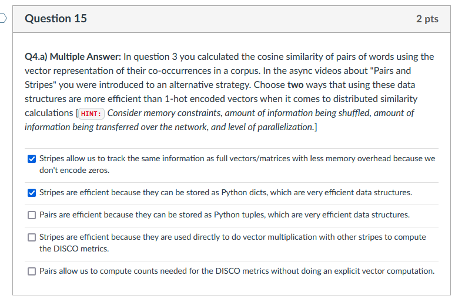

- **b) Read Provided Code:** The code below provides a streamlined implementation of document similarity analysis in Spark. Read through this code carefully. Once you are confident you understand how it works, answer the remaining questions. [**`TIP:`** *to see the output of each transformation try commenting out the subsequent lines and adding an early `collect()` action*.]
- **c) Multiple Answer on Digital Campus:** The second mapper function, `splitWords`, emits 'postings'. The list of all 'postings' for a word is also refered to as an 'inverted index'. Choose **three** true statements regarding 'postings' and an 'inverted index' based on your reading of the provided code. (*DITP by Lin and Dyer also contains a chapter on the Inverted Index although in the context of Hadoop rather than Spark. You may find the illustration in Chapter 4 helpful in answering this question*).

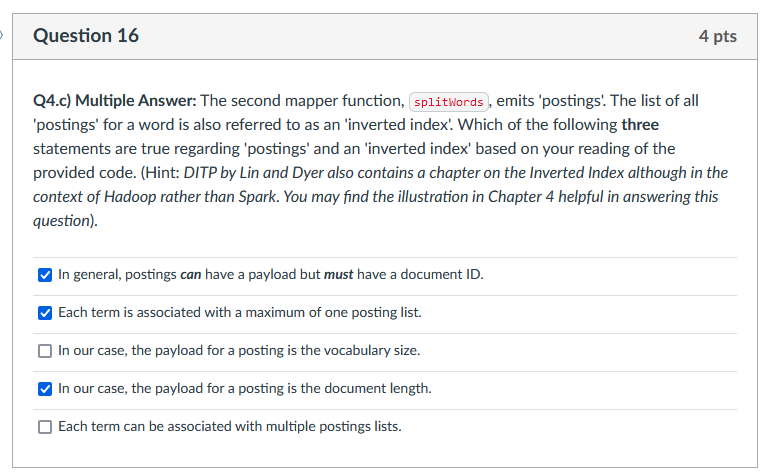

- **d) Multiple Dropdowns on Digital Campus:** The third mapper, `makeCompositeKeys`, loops over the inverted index to emit 'pairs' of what? Explain what information is included in the composite key created at this stage and why it makes sense to synchronize around that information in the context of performing document similarity calculations. In addition to the information included in these new keys, what other piece of information will we need to compute Jaccard or Cosine similarity?

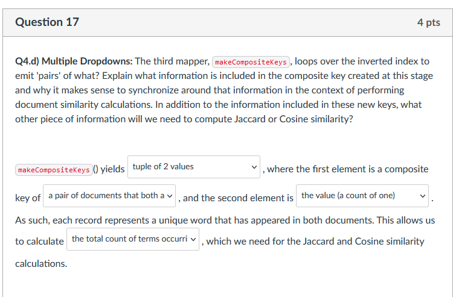

- **e) Multiple Choice on Digital Campus:** Out of all the Spark transformations we make in this analysis, which are 'wide' transformations and which are 'narrow' transformations, and why?

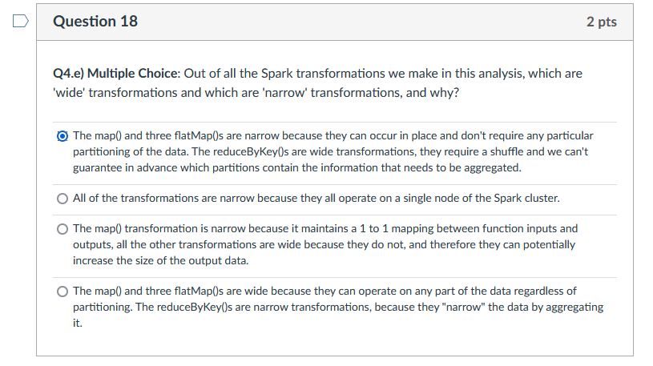

A small test file that we put in a folder on your private data bucket : **`sample_docs.txt`**

```python
sample_doc="""docA	bright blue butterfly forget
docB	best forget bright sky
docC	blue sky bright sun
docD	under butterfly sky hangs
docE	forget blue butterfly"""

sample_docs_loc = f'{HW3_FOLDER}/sample_docs.txt'

!echo "{sample_doc}" | gsutil cp - {sample_docs_loc}
```

```
Copying from <STDIN>...
/ [1 files][    0.0 B/    0.0 B]
Operation completed over 1 objects.
```

```python
!gsutil ls -l {HW3_FOLDER}
```

```
    445368  2023-06-18T22:54:35Z  gs://w261-hr/notebooks/jupyter/Assignments/HW3/hw3_Workbook-HR.ipynb
    111306  2023-05-20T20:20:22Z  gs://w261-hr/notebooks/jupyter/Assignments/HW3/hw3_Workbook.ipynb
      1218  2023-05-20T20:20:22Z  gs://w261-hr/notebooks/jupyter/Assignments/HW3/readme.md
       145  2023-06-18T22:55:28Z  gs://w261-hr/notebooks/jupyter/Assignments/HW3/sample_docs.txt
    500954  2023-05-20T20:20:22Z  gs://w261-hr/notebooks/jupyter/Assignments/HW3/scaling-up-similarity-search.pdf
                                 gs://w261-hr/notebooks/jupyter/Assignments/HW3/data/
TOTAL: 5 objects, 1058991 bytes (1.01 MiB)
```

```python
# load data - RUN THIS CELL AS IS
!gsutil cat {sample_docs_loc}
```

```
docA	bright blue butterfly forget
docB	best forget bright sky
docC	blue sky bright sun
docD	under butterfly sky hangs
docE	forget blue butterfly
```

**Document Similarity Analysis in Spark:**

```python
# load data - RUN THIS CELL AS IS
data = sc.textFile(sample_docs_loc)
```

```python
# helper function - RUN THIS CELL AS IS
def splitWords(pair):
    """Mapper 2: tokenize each document and emit postings."""
    doc, text = pair
    words = text.split(" ")
    for w in words:
        yield (w, [ (doc, len(words)) ])
```

```python
# helper function - RUN THIS CELL AS IS
def makeCompositeKey(inverted_index):
    """Mapper 3: loop over postings and yield pairs."""
    word, postings = inverted_index
    # taking advantage of symmetry, output only (a,b), but not (b,a)
    for subset in itertools.combinations(sorted(postings), 2):
        yield (str(subset), 1)
```

```python
# helper function - RUN THIS CELL AS IS
def jaccard(line):
    """Mapper 4: compute similarity scores"""
    (doc1, n1), (doc2, n2) = ast.literal_eval(line[0])
    total = int(line[1])
    jaccard = total / float(int(n1) + int(n2) - total)
    yield doc1+" - "+doc2, jaccard
```

### ignore latency warnings

NOTE: do NOT be alarmed if you see some latency warnings when you run the following command. This can happen when you are accessing your cloud bucket for the first time. Spark is super EAGER!

```python
# Spark Job - RUN THIS CELL AS IS
result = data.map(lambda line: line.split('\t')) \
             .flatMap(splitWords) \
             .reduceByKey(lambda x,y : x+y) \
             .flatMap(makeCompositeKey).collect() # \
#              .reduceByKey(lambda x,y : x+y) \
#              .flatMap(jaccard) \
#              .takeOrdered(10, key=lambda x: -x[1])
result
#NOTE: do NOT be alarmed if you see some latency warnings here. You ar
```

```
[("(('docA', 4), ('docB', 4))", 1),
 ("(('docA', 4), ('docC', 4))", 1),
 ("(('docB', 4), ('docC', 4))", 1),
 ("(('docA', 4), ('docD', 4))", 1),
 ("(('docA', 4), ('docE', 3))", 1),
 ("(('docD', 4), ('docE', 3))", 1),
 ("(('docB', 4), ('docC', 4))", 1),
 ("(('docB', 4), ('docD', 4))", 1),
 ("(('docC', 4), ('docD', 4))", 1),
 ("(('docA', 4), ('docC', 4))", 1),
 ("(('docA', 4), ('docE', 3))", 1),
 ("(('docC', 4), ('docE', 3))", 1),
 ("(('docA', 4), ('docB', 4))", 1),
 ("(('docA', 4), ('docE', 3))", 1),
 ("(('docB', 4), ('docE', 3))", 1)]
```

# ✅ About the Data and EDA

Now that you are comfortable with similarity metrics we turn to the main task in this assignment: "Synonym" Detection. As you saw in Question 3 the ability of our algorithm to detect words with similar meanings is highly dependent on our input text. Specifically, we need a large enough corpus of natural language that we can expose our algorithm to a realistic range of contexts in which any given word might get used. Ideally, these 'contexts' would also provide enough signal to distinguish between words with similar semantic roles but different meaning. Finding such a corpus will be easier to accomplish for some words than others.

For the main task in this portion of the homework you will use data from Google's n-gram corpus. This data is particularly convenient for our task because Google has already done the first step for us: they windowed over a large subset of the web and extracted all 5-grams. If you are interested in learning more about this dataset the original source is: http://books.google.com/ngrams/, and a large subset is available [here from AWS](https://aws.amazon.com/datasets/google-books-ngrams/).

Each row in our dataset represents one of these 5 grams in the format:

> `(ngram) \t (count) \t (pages_count) \t (books_count)`

**DISCLAIMER**: In real life, we would calculate the stripes cooccurrence data from the raw text by windowing over the raw text and not from the 5-gram preprocessed data. Calculating pairs on this 5-gram is a little corrupt as we will be double counting cooccurences. Having said that this exercise can still pull out some similar terms.

```python
!gsutil ls -lh {HW3_FOLDER}/data |head -5 #The data is preloaded into your personal data bucket (all 190 zipped files)
```

```
  3.66 MiB  2023-05-20T20:20:11Z  gs://w261-hr/notebooks/jupyter/Assignments/HW3/data/googlebooks-eng-all-5gram-20090715-0-filtered.txt.gz
      70 B  2023-05-20T20:20:11Z  gs://w261-hr/notebooks/jupyter/Assignments/HW3/data/googlebooks-eng-all-5gram-20090715-1-filtered.txt.gz
  3.66 MiB  2023-05-20T20:20:12Z  gs://w261-hr/notebooks/jupyter/Assignments/HW3/data/googlebooks-eng-all-5gram-20090715-10-filtered.txt.gz
  3.67 MiB  2023-05-20T20:20:12Z  gs://w261-hr/notebooks/jupyter/Assignments/HW3/data/googlebooks-eng-all-5gram-20090715-100-filtered.txt.gz
  3.67 MiB  2023-05-20T20:20:12Z  gs://w261-hr/notebooks/jupyter/Assignments/HW3/data/googlebooks-eng-all-5gram-20090715-101-filtered.txt.gz
Exception ignored in: <_io.TextIOWrapper name='<stdout>' mode='w' encoding='utf-8'>
BrokenPipeError: [Errno 32] Broken pipe
```

```python
# set global paths to full data folder and to the first file (which we'll use for testing)
NGRAMS  = f'{HW3_FOLDER}/data'
F1_PATH = f'{HW3_FOLDER}/data/googlebooks-eng-all-5gram-20090715-0-filtered.txt.gz'
```

As you develop your code you should use the following file to systems test each of your solutions before running it on the Google data. (Note: these are the 5-grams extracted from our two line Dickens corpus in Question 3... you should find that your Spark job results match the calculations we did "by hand").

Test file: **`systems_test.txt`**

```python
systems_test= """it was the best of	1	1	1
age of wisdom it was	1	1	1
best of times it was	1	1	1
it was the age of	2	1	1
it was the worst of	1	1	1
of times it was the	2	1	1
of wisdom it was the	1	1	1
the age of wisdom it	1	1	1
the best of times it	1	1	1
the worst of times it	1	1	1
times it was the age	1	1	1
times it was the worst	1	1	1
was the age of wisdom	1	1	1
was the best of times	1	1	1
was the age of foolishness	1	1	1
was the worst of times	1	1	1
wisdom it was the age	1	1	1
worst of times it was	1	1	1"""


systems_test_loc = f'{HW3_FOLDER}/systems_test.txt'

!echo "{systems_test}" | gsutil cp - {systems_test_loc}
```

```
Copying from <STDIN>...
/ [1 files][    0.0 B/    0.0 B]
Operation completed over 1 objects.
```

Finally, we'll create a Spark RDD for each of these files so that they're easy to access throughout the rest of the assignment.

```python
# Spark RDDs for each dataset
testRDD = sc.textFile(systems_test_loc)
f1RDD = sc.textFile(F1_PATH)
dataRDD = sc.textFile(NGRAMS)
```

Let's take a peek at what each of these RDDs looks like:

```python
testRDD.take(10)
```

```
['it was the best of\t1\t1\t1',
 'age of wisdom it was\t1\t1\t1',
 'best of times it was\t1\t1\t1',
 'it was the age of\t2\t1\t1',
 'it was the worst of\t1\t1\t1',
 'of times it was the\t2\t1\t1',
 'of wisdom it was the\t1\t1\t1',
 'the age of wisdom it\t1\t1\t1',
 'the best of times it\t1\t1\t1',
 'the worst of times it\t1\t1\t1']
```

```python
f1RDD.take(10)
```

```
['A BILL FOR ESTABLISHING RELIGIOUS\t59\t59\t54',
 'A Biography of General George\t92\t90\t74',
 'A Case Study in Government\t102\t102\t78',
 'A Case Study of Female\t447\t447\t327',
 'A Case Study of Limited\t55\t55\t43',
 "A Child's Christmas in Wales\t1099\t1061\t866",
 'A Circumstantial Narrative of the\t62\t62\t50',
 'A City by the Sea\t62\t60\t49',
 'A Collection of Fairy Tales\t123\t117\t80',
 'A Collection of Forms of\t116\t103\t82']
```

```python
dataRDD.take(10)
```

```
['A BILL FOR ESTABLISHING RELIGIOUS\t59\t59\t54',
 'A Biography of General George\t92\t90\t74',
 'A Case Study in Government\t102\t102\t78',
 'A Case Study of Female\t447\t447\t327',
 'A Case Study of Limited\t55\t55\t43',
 "A Child's Christmas in Wales\t1099\t1061\t866",
 'A Circumstantial Narrative of the\t62\t62\t50',
 'A City by the Sea\t62\t60\t49',
 'A Collection of Fairy Tales\t123\t117\t80',
 'A Collection of Forms of\t116\t103\t82']
```

## ✅ Question 5: N-gram EDA part 1 (words)

Before starting our synonym-detection, let's get a sense for this data. As you saw in questions 3 and 4 the size of the vocabulary will impact the amount of computation we have to do. Write a Spark job that will accomplish the three tasks below as efficiently as possible. (No credit will be awarded for jobs that sort or subset after calling `collect()`-- use the framework to get the minimum information requested). As you develop your code, systems test each job on the provided file with Dickens ngrams, then on a single file from the Ngram dataset before running the full analysis.

### Q5 Tasks:

- **a) Code in Notebook and Submit a Screenshot on Digital Campus:** Write a Spark application to retrieve:
  - The number of unique words that appear in the data. (i.e. size of the vocabulary)
  - A list of the top 10 words & their counts.
  - A list of the bottom 10 words & their counts.

  **`NOTE 1:`** *don't forget to lower case the ngrams before extracting words.*  
  **`NOTE 2:`** *don't forget to take in to account the number of occurrences (`count`) of each ngram.*  
  **`NOTE 3:`** *to make this code more reusable, the `EDA1` function code base uses a parameter 'n' to specify the number of top/bottom words to print (in this case we've requested 10).*
- **b) Numeric on Digital Campus:** What is the size of the vocabulary in `dataRDD`?

> 269339
- **c) Numeric on Digital Campus:** Given the vocab size you just found, how many potential synonym pairs could we form from this corpus?

> ${269339 \choose 2} = 36271613791$
- **d) Numeric on Digital Campus:** If each term's stripe were 1000 words long, how many tuples would we need to shuffle in order to form the inverted indices?

> 269,339,000
> - **e) Short Response on Digital Campus:** Show and briefly explain your calculations for each part of this question. Be sure to use the Equation Editor/Latex. [**`HINT:`** see your work from q4 for a review of these concepts.]

> This essentially is $\alpha * \beta$ where $\alpha =$ vocabulary size and $\beta = $ stripe length. So in this case we would have $269339*1000 = 269,339,000$.
- **f) Multiple Choice on Digital Campus:** Looking at the most frequent words and their counts, how useful will these top words be in synonym detection?

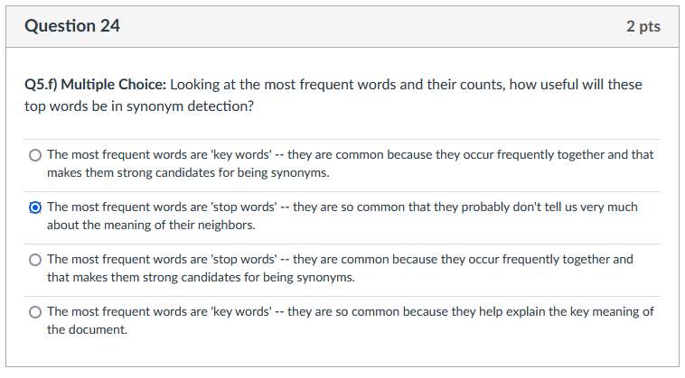

- **g) Multiple Choice on Digital Campus:** Looking at the least frequent words and their counts, what is a possible explanation of their low counts?

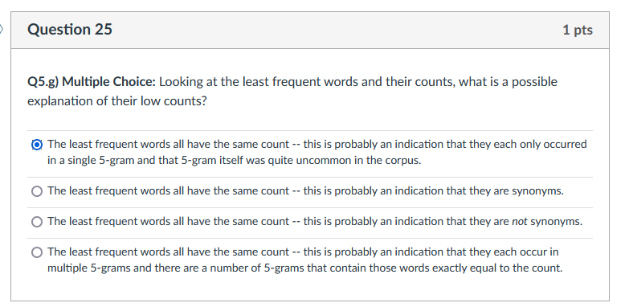

- **h) Multiple Choice on Digital Campus:** How reliable should we expect the detected 'synonyms' for the least frequent words to be?

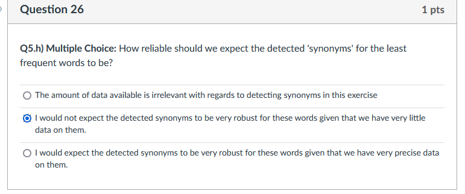

```python
# part a - write your spark job here
def EDA1(rdd, n):
    total, top_n, bottom_n = None, None, None
    # Each row in our dataset represents one of these 5 grams in the format:
    # > `(ngram) \t (count) \t (pages_count) \t (books_count)`
    #            'it was the age of\t2\t1\t1'
    # Each rocord has:  ngram, count, ignore other fields
    ############# YOUR CODE HERE ###############
    def countMapper(payload):
        terms = payload[0].lower()
        count = payload[1]
        terms = terms.split()
        for term in terms:
            yield (term, int(count))
    result = rdd.map(lambda x: x.split('\t')) \
        .flatMap(countMapper) \
        .reduceByKey(lambda x, y: x + y)
    total = result.count()
    top_n = result.top(n, key=lambda x: x[1])
    bottom_n = result.top(n, key=lambda x: -x[1])


    ############# (END) YOUR CODE ##############
    return total, top_n, bottom_n
```

```python
# part a - run the system test (RUN THIS CELL AS IS... use display cell below to see results)
import time
start = time.time()
vocab_size, most_frequent, least_frequent = EDA1(testRDD, 10)
print("Wall time: {} seconds".format(time.time() - start))
```

```
Wall time: 0.2610039710998535 seconds
```

```python
# part a - display results (feel free to modify the formatting code if needed)
print("Vocabulary Size:", vocab_size)
print(" ---- Top Words ----|--- Bottom Words ----")
for (w1, c1), (w2, c2) in zip(most_frequent, least_frequent):
    print(f"{w1:>8} {c1:>10} |{w2:>15} {c2:>3}")
```

```
Vocabulary Size: 10
 ---- Top Words ----|--- Bottom Words ----
     was         17 |    foolishness   1
      of         17 |           best   4
     the         17 |          worst   5
      it         16 |         wisdom   5
   times         10 |            age   8
     age          8 |          times  10
   worst          5 |             it  16
  wisdom          5 |            was  17
    best          4 |             of  17
foolishness          1 |            the  17
```

Expected output for testRDD:

```
    Vocabulary Size: 10
 ---- Top Words ----|--- Bottom Words ----
     was         17 |    foolishness   1
      of         17 |           best   4
     the         17 |          worst   5
      it         16 |         wisdom   5
   times         10 |            age   8
     age          8 |          times  10
   worst          5 |             it  16
  wisdom          5 |            was  17
    best          4 |             of  17
foolishness       1 |            the  17
```

```python
# part a - run a single file, ie., a small sample (RUN THIS CELL AS IS)
start = time.time()
vocab_size, most_frequent, least_frequent = EDA1(f1RDD, 10)
print("Wall time: {} seconds".format(time.time() - start))
```

```
[Stage 56:>                                                         (0 + 1) / 1]
```

```
Wall time: 2.2952048778533936 seconds
```

```python
# part a - display results (feel free to modify the formatting code if needed)
print("Vocabulary Size:", vocab_size)
print(" ---- Top Words ----|--- Bottom Words ----")
for (w1, c1), (w2, c2) in zip(most_frequent, least_frequent):
    print(f"{w1:>8} {c1:>10} |{w2:>15} {c2:>3}")
```

```
Vocabulary Size: 36353
 ---- Top Words ----|--- Bottom Words ----
     the   27691943 |    stakeholder  40
      of   18590950 |          kenny  40
      to   11601757 |       jonathan  40
      in    7470912 |         barnes  40
       a    6926743 |         arnall  40
     and    6150529 |       copybook  40
    that    4077421 |     buonaparte  40
      is    4074864 |       puzzling  40
      be    3720812 |             ae  40
     was    2492074 |       kennelly  40
```

Expected output for f1RDD

```
Vocabulary Size: 36353
 ---- Top Words ----|--- Bottom Words ----
     the   27691943 |    stakeholder  40
      of   18590950 |          kenny  40
      to   11601757 |         barnes  40
      in    7470912 |         arnall  40
       a    6926743 |     buonaparte  40
     and    6150529 |       puzzling  40
    that    4077421 |             hd  40
      is    4074864 |        corisca  40
      be    3720812 |       cristina  40
     was    2492074 |         durban  40
```

```python
# part a - run full analysis (RUN THIS CELL AS IS)

start = time.time()
vocab_size, most_frequent, least_frequent = EDA1(dataRDD, 10)
print("Wall time: {} seconds".format(time.time() - start))
# Command took 4 minute minutes on N1-Std-4 (4 CPUS) as May 30, 2022
#
```

```
[Stage 67:=====================================================>(188 + 2) / 190]
```

```
Wall time: 113.06834363937378 seconds
```

```python
# part a - display results (feel free to modify the formatting code if needed)
print("Vocabulary Size:", vocab_size)
print(" ---- Top Words ----|--- Bottom Words ----")
for (w1, c1), (w2, c2) in zip(most_frequent, least_frequent):
    print(f"{w1:>8} {c1:>10} |{w2:>15} {c2:>3}")
```

```
Vocabulary Size: 269339
 ---- Top Words ----|--- Bottom Words ----
     the 5490815394 |    unmurmuring  40
      of 3698583299 |    scribbler's  40
      to 2227866570 |      washermen  40
      in 1421312776 |    viscerating  40
       a 1361123022 |         mildes  40
     and 1149577477 |       jaworski  40
    that  802921147 |            rll  40
      is  758328796 |          porti  40
      be  688707130 |     foretastes  40
      as  492170314 |       parcival  40
```

Expected output for dataRDD: (bottom words might vary a little due to ties)

```
Vocabulary Size: 269339
 ---- Top Words ----|--- Bottom Words ----
     the 5490815394 |   schwetzingen  40
      of 3698583299 |           cras  40
      to 2227866570 |       parcival  40
      in 1421312776 |          porti  40
       a 1361123022 |    scribbler's  40
     and 1149577477 |      washermen  40
    that  802921147 |    viscerating  40
      is  758328796 |         mildes  40
      be  688707130 |      scholared  40
      as  492170314 |       jaworski  40
```

# ✅ Question 6: N-gram EDA part 2 (co-occurrences)

The computational complexity of synonym analysis depends not only on the number of words, but also on the number of co-ocurrences each word has. In this question you'll take a closer look at that aspect of our data. As before, please test each job on small "systems test" (Dickens ngrams) file and on a single file from the Ngram dataset before running the full analysis.

### Q6 Tasks:

- **a) Code in Notebook and Submit a Screenshot on Digital Campus:** Write a spark job that computes:
  - the number of unique neighbors (i.e. 5-gram co-occuring words) for each word in the vocabulary.
    - For example, given a five-gram `a b c a b` our desired output of the number of unique neighbors for each unique word as follows: is a:2, b:2, c:2 (from pairs {'a-b', 'b-c', 'a-c'})
    - More generally, for a single ngram the number of unique co-occuring words is `N-1`, where is `N` is the number of unique words in the n-gram.
    - The above five-gram `a b c a b` has 3 unique words where each word has 2 unique neighors (different to itself)
    - For "a b c d e", each unique word has a 4 neighbors

The following code demonstrates this neighbor count in action on a single core machine:

```
import itertools
import numpy as np

def get_num_of_uniq_neighbors(a_str = "a b c a b")
    words = a_str.split()
    # we are looking for neighbors of each word (regardless of location in the n-gram context)
    # pair (a b) is same as pair (b a)
    pairs_list = [] # all pair combinations
    pairs = set()   # just unique pair combinations
    for i, pair in enumerate(itertools.combinations(words, 2)):
        if pair[0] != pair[1]:
            pair_str = "{}-{}".format(*sorted(pair)) #sort to make pair (a b) the same as pair (b a)
            #print(f"pair {i+1}: {pair_str}")
            pairs.add(pair_str)
            pairs_list+=[pair_str]
    print(f"pairs_list: {pairs_list}")
    print(f"uniq pairs: {pairs}")
    unigrams = [unigram for bigram in pairs for unigram in bigram.split("-")]
    print(f"unigrams: {unigrams}")
    for unigram in set(unigrams):
        print(f"{unigram}: {sum(np.char.count(unigrams, unigram))}")

get_num_of_uniq_neighbors(a_str = "a b c a b")
get_num_of_uniq_neighbors(a_str = "a b c d e")

#pairs_list: ['a-b', 'a-c', 'a-b', 'b-c', 'a-b', 'a-c', 'b-c', 'a-b'] #dropped "a-a" and "b-b"
#uniq pairs: {'a-b', 'b-c', 'a-c'}
#unigrams: ['a', 'b', 'b', 'c', 'a', 'c']
# a: 2
# b: 2
# c: 2
.....
d:4
e:4
```

```
  HINT 2: consider all words within a five-gram to be co-occuring. In other words, a word in a single 5-gram will always have 4 neighbors
  EXAMPLE:
    the dog ate cat litter
    the cat has clean litter

    Vocabulary:
    the, dog, ate, litter, cat, has, clean

    Neighbors:
    (the, dog) (the, ate) (the, cat) (the, littler), (dog, ate) (dog, cat) (dog, litter), (ate, cat) (ate, litter), (cat, litter)
    (the, cat) (the, has) (the, clean) (the, litter), (cat, has) (cat, clean) (cat, litter), (has, clean) (has, litter) (clean, litter)

    Unique neighbors:
    the 6
    dog 4
    ate 4
    litter 6
    cat 6
    has 4
    clean 4
```

- the top 10 words with the most "neighbors"
- the bottom 10 words with least "neighbors"
- a random sample of 1% of the words' neighbor counts

[**`NOTE:`** for the last item, please return only the counts and not the words -- we'll go on to use these in a plotting function that expects a list of integers. Additionally, we'll say for the purposes of this assignment that a word cannot be a neighbor with itself. For example, (cat, cat) wouldn't be valid.]

- **b) Multiple Answer on Digital Campus:** Use the provided code to plot a histogram of the sampled list from `a`. Comment on the distribution you observe. How will this distribution affect our synonym detection analysis?

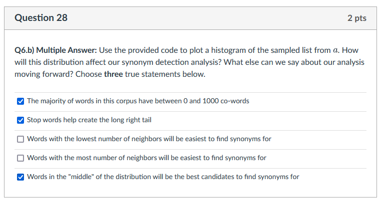

- **c) Code in Notebook and Submit a Screenshot on Digital Campus:** Write a Spark Job to compare word frequencies to number of neighbors.

[**`NOTE:`** *technically these lists are short enough to compare in memory on your local machine but please design your Spark job as if we were potentially comparing much larger lists.*]

- **d) Numeric on Digital Campus:** Of the 1000 words with most neighbors, what percent are also in the list of 1000 most frequent words?

> 88%
- **e) Numeric on Digital Campus:** Of the 1000 words with least neighbors, what percent are also in the list of 1000 least frequent words?

> 1.9%

```python
# HINT: run cell as is
import itertools
import numpy as np
def get_num_of_uniq_neighbors(a_str = "a b c a b"):
    words = a_str.split()
    # we are looking for neighbors of each word (regardless of location in the n-gram context)
    # pair (a b) is same as pair (b a)
    pairs_list = [] # all pair combinations
    pairs = set()   # just unique pair combinations
    for i, pair in enumerate(itertools.combinations(words, 2)):
        if pair[0] != pair[1]:
            pair_str = "{}-{}".format(*sorted(pair)) #sort to make pair (a b) the same as pair (b a)
            #print(f"pair {i+1}: {pair_str}")
            pairs.add(pair_str)
            pairs_list+=[pair_str]
    print(f"pairs_list: {pairs_list}")
    print(f"uniq pairs: {pairs}")
    unigrams = [unigram for bigram in pairs for unigram in bigram.split("-")]
    print(f"unigrams: {unigrams}")
    for unigram in set(unigrams):
        print(f"{unigram}: {sum(np.char.count(unigrams, unigram))}")

get_num_of_uniq_neighbors(a_str = "a b c a b")
get_num_of_uniq_neighbors(a_str = "a b c d e")

#  output
#pairs_list: ['a-b', 'a-c', 'a-b', 'b-c', 'a-b', 'a-c', 'b-c', 'a-b'] #dropped "a-a" and "b-b"
#uniq pairs: {'a-b', 'b-c', 'a-c'}
#unigrams: ['a', 'b', 'b', 'c', 'a', 'c']
# a: 2
# b: 2
# c: 2
```

```
pairs_list: ['a-b', 'a-c', 'a-b', 'b-c', 'a-b', 'a-c', 'b-c', 'a-b']
uniq pairs: {'a-c', 'a-b', 'b-c'}
unigrams: ['a', 'c', 'a', 'b', 'b', 'c']
a: 2
c: 2
b: 2
pairs_list: ['a-b', 'a-c', 'a-d', 'a-e', 'b-c', 'b-d', 'b-e', 'c-d', 'c-e', 'd-e']
uniq pairs: {'c-d', 'b-d', 'a-e', 'a-d', 'b-e', 'c-e', 'a-c', 'b-c', 'a-b', 'd-e'}
unigrams: ['c', 'd', 'b', 'd', 'a', 'e', 'a', 'd', 'b', 'e', 'c', 'e', 'a', 'c', 'b', 'c', 'a', 'b', 'd', 'e']
a: 4
c: 4
e: 4
b: 4
d: 4
```

```python
# part a - spark job
def EDA2(rdd,n):
    top_n, bottom_n, sampled_counts = None, None, None
    ############# YOUR CODE HERE ###############

    def neighbour_mapper(payload):
        terms = payload[0].lower()
        count = int(payload[1])
        terms = terms.split()
        pairs = set()
        for i, pair in enumerate(itertools.combinations(terms, 2)):
            if pair[0] != pair[1]:
                pair_str = "{}-{}".format(*sorted(pair)) #sort to make pair (a b) the same as pair (b a)
                #print(f"pair {i+1}: {pair_str}")
                pairs.add(pair_str)
        for pair in pairs:
            yield (pair, count)

    def double_words(x):
        combo = x[0].split('-')
        # we want to output both pairs, because we'll (count neighbours) by key, which will be the first element in the tuple
        # so we want to count the neighbours for both alpha and beta terms in the x tuple (alpha, beta)
        yield (combo[0], 1)
        yield (combo[1], 1)

    result = rdd.map(lambda x: x.split('\t')) \
        .flatMap(neighbour_mapper)  \
        .reduceByKey(lambda x, y: 1) \
        .flatMap(double_words) \
        .reduceByKey(lambda x, y: x + y)

    top_n = result.top(n, key=lambda x: x[1])
    bottom_n = result.top(n, key=lambda x: -x[1])
    sampled_counts = result.sample(False, .01, 2).map(lambda x: x[1]).collect()

    ############# (END) YOUR CODE ##############
    return top_n, bottom_n, sampled_counts
```

```python
# part a - systems test (RUN THIS CELL AS IS)
start = time.time()
most_nbrs, least_nbrs, sample_counts = EDA2(testRDD, 10)
print("Wall time: {} seconds".format(time.time() - start))
# Command took 0.83 seconds -- by kyleiwaniec@gmail.com at 12/8/2020, 1:41:59 PM on HW-S21
```

```
Wall time: 0.256072998046875 seconds
```

```python
# part a - display results (feel free to modify the formatting code if needed)
print(" --- Most Co-Words ---|--- Least Co-Words ----")
for (w1, c1), (w2, c2) in zip(most_nbrs, least_nbrs):
    print(f"{w1:>12} {c1:>8} |{w2:>16} {c2:>4}")
```

```
 --- Most Co-Words ---|--- Least Co-Words ----
         was        9 |     foolishness    4
          of        9 |            best    5
         the        9 |           worst    5
          it        8 |          wisdom    5
         age        7 |             age    7
       times        7 |           times    7
        best        5 |              it    8
       worst        5 |             was    9
      wisdom        5 |              of    9
 foolishness        4 |             the    9
```

Expected output for testRDD:

```
 --- Most Co-Words ---|--- Least Co-Words ----
         was        9 |     foolishness    4
          of        9 |            best    5
         the        9 |           worst    5
          it        8 |          wisdom    5
         age        7 |             age    7
       times        7 |           times    7
        best        5 |              it    8
       worst        5 |             was    9
      wisdom        5 |              of    9
 foolishness        4 |             the    9
```

```python
# part a - single file test (RUN THIS CELL AS IS)
start = time.time()
most_nbrs, least_nbrs, sample_counts = EDA2(f1RDD, 10)
print("Wall time: {} seconds".format(time.time() - start))
# Command took 13.80 seconds -- DCE

#[Stage 40:>                                                         (0 + 1) / 1]
#Wall time: 10.146554470062256 seconds

#[Stage 50:>                                                         (0 + 4) / 4]
# Wall time: 6.513125658035278 seconds
```

```
[Stage 116:>                                                        (0 + 1) / 1]
```

```
Wall time: 8.95975112915039 seconds
```

```python
# part a - display results (feel free to modify the formatting code if needed)
print(" --- Most Co-Words ---|--- Least Co-Words ----")
for (w1, c1), (w2, c2) in zip(most_nbrs, least_nbrs):
    print(f"{w1:>12} {c1:>8} |{w2:>16} {c2:>4}")
```

```
 --- Most Co-Words ---|--- Least Co-Words ----
         the    25548 |              vo    1
          of    22496 |             gem    2
         and    16489 |           pizza    2
          to    14249 |            hoot    2
          in    13891 |     palpitation    2
           a    13045 |      noncleaved    2
        that     8011 |            twel    2
          is     7947 |             sud    2
        with     7552 |          dalles    2
          by     7400 |        premiers    2
```

Expected output for f1RDD:

```
 --- Most Co-Words ---|--- Least Co-Words ----
         the    25548 |              vo    1
          of    22496 |      noncleaved    2
         and    16489 |        premiers    2
          to    14249 |        enclaves    2
          in    13891 |   selectiveness    2
           a    13045 |           trill    2
        that     8011 |           pizza    2
          is     7947 |            hoot    2
        with     7552 |     palpitation    2
          by     7400 |            twel    2
```

```python
# part a - full data (RUN THIS CELL AS IS)
start = time.time()
most_nbrs, least_nbrs, sample_counts = EDA2(dataRDD, 10)
print("Wall time: {} seconds".format(time.time() - start))

# Wall time: 796.3152396678925 seconds on n1-std-4 (with gunzipped txt files)
```

```
[Stage 132:==============================================>      (168 + 8) / 190]
```

```
Wall time: 377.74582958221436 seconds
```

```python
# part a - display results (feel free to modify the formatting code if needed)
print(" --- Most Co-Words ---|--- Least Co-Words ----")
for (w1, c1), (w2, c2) in zip(most_nbrs, least_nbrs):
    print(f"{w1:>12} {c1:>8} |{w2:>16} {c2:>4}")
```

```
 --- Most Co-Words ---|--- Least Co-Words ----
         the   164982 |          cococo    1
          of   155708 |            inin    1
         and   132814 |        charuhas    1
          in   110615 |         ooooooo    1
          to    94358 |           iiiii    1
           a    89197 |          iiiiii    1
          by    67266 |             cnj    1
        with    65127 |            choh    1
        that    61174 |             neg    1
          as    60652 |      cococococo    1
```

Expected output for dataRDD: (bottom words might vary a little due to ties)

```
 --- Most Co-Words ---|--- Least Co-Words ----
         the   164982 |          cococo    1
          of   155708 |            inin    1
         and   132814 |        charuhas    1
          in   110615 |         ooooooo    1
          to    94358 |           iiiii    1
           a    89197 |          iiiiii    1
          by    67266 |             cnj    1
        with    65127 |            choh    1
        that    61174 |             neg    1
          as    60652 |      cococococo    1
```

**`NOTE:`** *before running the plotting code below, make sure that the variable* `sample_counts` *points to the list generated in* `part a`.

```
NOTE: we'll exclude the 8 words with more than 6000 nbrs in this 2635 count sample.
```

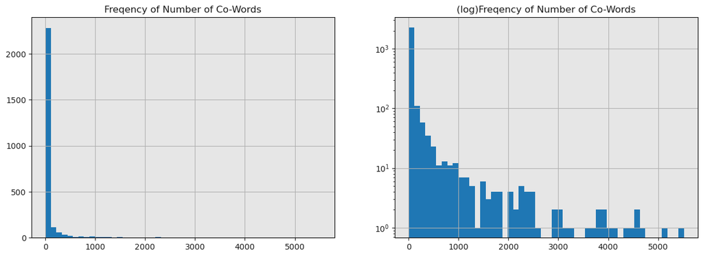

```python
# part b - plot histogram (RUN THIS CELL AS IS - feel free to modify format)

# removing extreme upper tail for a better visual
counts = np.array(sample_counts)[np.array(sample_counts) < 6000]
t = sum(np.array(sample_counts) > 6000)
n = len(counts)
print("NOTE: we'll exclude the %s words with more than 6000 nbrs in this %s count sample." % (t,n))

# set up figure
fig, (ax1, ax2) = plt.subplots(1,2, figsize = (15,5))

# plot regular hist
ax1.hist(counts, bins=50)
ax1.set_title('Freqency of Number of Co-Words', color='0.1')
ax1.set_facecolor('0.9')
ax1.tick_params(axis='both', colors='0.1')
ax1.grid(True)

# plot log scale hist
ax2.hist(counts, bins=50)
ax2.set_title('(log)Freqency of Number of Co-Words', color='0.1')
ax2.set_facecolor('0.9')
ax2.tick_params(axis='both', colors='0.1')
ax2.grid(True)
plt.yscale('log')
```

```python
# part c - spark job
def compareRankings(rdd1, rdd2):
    percent_overlap = None
    ############# YOUR CODE HERE ###############

    total_count = rdd1.count()
    percent_overlap = (rdd1.map(lambda x: x[0]).intersection(rdd2.map(lambda x: x[0])).count() / float(total_count))*100

    ############# (END) YOUR CODE ##############
    return percent_overlap
```

```python
# part d/e - get lists for comparison (RUN THIS CELL AS IS...)
# (... then change 'testRDD' to 'f1RDD'/'dataRDD' when ready)
total, topWords, bottomWords = EDA1(dataRDD, 1000)
topNbrs, bottomNbrs, sample_counts = EDA2(dataRDD, 1000)
twRDD = sc.parallelize(topWords)
bwRDD = sc.parallelize(bottomWords)
tnRDD = sc.parallelize(topNbrs)
bnRDD = sc.parallelize(bottomNbrs)
top_overlap = compareRankings(tnRDD, twRDD)
bottom_overlap = compareRankings(bnRDD, bwRDD)
print(f"Of the 1000 words with most neighbors, {top_overlap} percent are also in the list of 1000 most frequent words.")
print(f"Of the 1000 words with least neighbors, {bottom_overlap} percent are also in the list of 1000 least frequent words.")
```

```
Of the 1000 words with most neighbors, 88.0 percent are also in the list of 1000 most frequent words.
Of the 1000 words with least neighbors, 1.9 percent are also in the list of 1000 least frequent words.
```

# Question 7: Basis Vocabulary & Stripes

Every word that appears in our data is a potential feature for our synonym detection analysis. However as we've discussed, some are likely to be more useful than others. In this question, you'll choose a judicious subset of these words to form our 'basis vocabulary'. Practically speaking, this means that when we build our stripes, we are only going to keep track of when a term co-occurs with one of these basis words.

### Q7 Tasks:

- **a) Multiple Choice on Digital Campus:** Suppose we were deciding between two different basis vocabularies: the 1000 most frequent words or the 1000 least frequent words. How would this choice impact the quality of the synonyms we are able to detect? How does this choice relate to the ideas of 'overfitting' or 'underfitting' a training set?

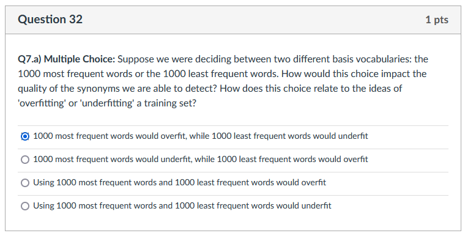

- **b) Short Response on Digital Campus:** Explain your answer above

> Using the 1K most frequent words is bound to give us more signal i.e. more variance, whereby we will have a larger number of uses that will inform our similarity. However, these represent the 1K words that are most frequent *in this particular corpus*. This approach may not generalise well to unseen vocabulary (for example, this could be a particularly technical corpus, which would not generalise to more general literature).
- **c) Multiple Choice on Digital Campus:** If we had a much larger dataset, computing the full ordered list of words would be extremely expensive. If we need to none-the-less get an estimate of word frequency in order to decide on a basis vocabulary, what alternative strategy could we take?

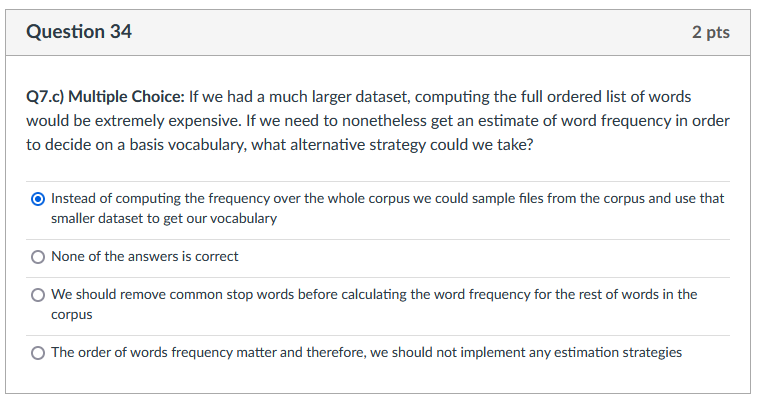

- **d) Multiple Choice on Digital Campus:** What is another way to describe the Basis Vocabulary in machine learning terms?

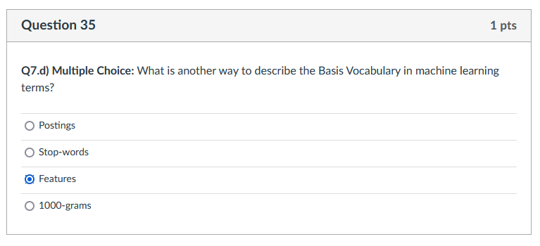

- **e) Code in Notebook and Submit a Screenshot on Digital Campus:** Complete the function `get_vocab()` and run the provided spark job that does the following:
  - tokenizes, removes stopwords and computes a word count on the ngram data
  - subsets the top 10,000 words (these are the terms we'll consider as potential synonyms)
  - subsets words 9,000-9,999 (this will be our 1,000 word basis vocabulary)  
    (to put it another way - of the top 10,000 words, the bottom 1,000 form the basis vocabulary)
  - saves the full 10K word list and the 1K basis vocabulary to file for use in `d`.
- **f) Code in Notebook and Submit a Screenshot on Digital Campus:** Write a spark job that builds co-occurrence stripes for the top 10K words in the ngram data using the basis vocabulary you developed in `part e`. This job/function, unlike others so far, should return an RDD (which we will then use in Q8).

```python
# part c - provided stopwords (RUN THIS CELL AS IS)
STOPWORDS =  ['i', 'me', 'my', 'myself', 'we', 'our', 'ours',
              'ourselves', 'you', 'your', 'yours', 'yourself',
              'yourselves', 'he', 'him', 'his', 'himself', 'she',
              'her', 'hers', 'herself', 'it', 'its', 'itself',
              'they', 'them', 'their', 'theirs', 'themselves',
              'what', 'which', 'who', 'whom', 'this', 'that',
              'these', 'those', 'am', 'is', 'are', 'was', 'were',
              'be', 'been', 'being', 'have', 'has', 'had', 'having',
              'do', 'does', 'did', 'doing', 'a', 'an', 'the', 'and',
              'but', 'if', 'or', 'because', 'as', 'until', 'while',
              'of', 'at', 'by', 'for', 'with', 'about', 'against',
              'between', 'into', 'through', 'during', 'before',
              'after', 'above', 'below', 'to', 'from', 'up', 'down',
              'in', 'out', 'on', 'off', 'over', 'under', 'again',
              'further', 'then', 'once', 'here', 'there', 'when',
              'where', 'why', 'how', 'all', 'any', 'both', 'each',
              'few', 'more', 'most', 'other', 'some', 'such', 'no',
              'nor', 'not', 'only', 'own', 'same', 'so', 'than',
              'too', 'very', 'should', 'can', 'now', 'will', 'just',
              'would', 'could', 'may', 'must', 'one', 'much', "it's",
              "can't", "won't", "don't", "shouldn't", "hasn't"]
```

```python
# part c - get the vocabulary and basis
#
def get_vocab(rdd, n_total, n_basis):
    vocab, basis = None, None
    ############# YOUR CODE HERE ###############

    def countMapper(payload):
        terms = payload[0].lower()
        count = payload[1]
        terms = terms.split()
        for term in terms:
            if term in STOPWORDS:
                continue
            yield (term, int(count))
    result = rdd.map(lambda x: x.split('\t')) \
        .flatMap(countMapper) \
        .reduceByKey(lambda x, y: x + y) \
        .sortBy(lambda x: -x[1]) \
        .map(lambda x: x[0]) # get only the words
    vocab = result.take(n_total)
    basis = vocab[-1*n_basis:]


    ############# (END) YOUR CODE ##############
    return vocab, basis
```

```python
# part c - run your job (RUN THIS CELL AS IS)
start = time.time()
VOCAB, BASIS = get_vocab(dataRDD, 10000, 1000)
print("Wall time: {} seconds".format(time.time() - start))
# 268.0176115036011 seconds
```

```
Wall time: 185.95951199531555 seconds
```

```python
# part c - save to file (RUN THIS CELL AS IS)
# with open("vocabulary.txt", "w") as file:
#     file.write(','.join(VOCAB))
# with open("basis.txt", "w") as file:
#     file.write(','.join(BASIS))
```

```python
# part c - save to file (RUN THIS CELL AS IS)
!echo "{','.join(VOCAB)}" | gsutil cp - {HW3_FOLDER}/output/vocabulary.txt
!echo "{','.join(BASIS)}" | gsutil cp - {HW3_FOLDER}/output/basis.txt
```

```
Copying from <STDIN>...
/ [1 files][    0.0 B/    0.0 B]
Operation completed over 1 objects.
Copying from <STDIN>...
/ [1 files][    0.0 B/    0.0 B]
Operation completed over 1 objects.
```

```python
# part d - spark job
# builds co-occurrence stripes for the top 10K words in the ngram data using the basis vocabulary you developed in part e. This job/function, unlike others so far, should return an RDD (which we will then use in Q8).
def buildStripes(rdd, vocab, basis):
    stripesRDD = None
    ############# YOUR CODE HERE ###############
    vocab = set(vocab)
    basis = set(basis)
    def stripe_mapper(payload):
        line, *c = payload.split('\t')
        terms = line.lower()
        terms = terms.split()
        vocab_terms = set()
        basis_terms = set()

        for term in terms:
            if term in STOPWORDS:
                continue
            if term in vocab:
                vocab_terms.add(term)
            if term in basis:
                basis_terms.add(term)

        for vt in vocab_terms:
            basis_vec = basis_terms - {vt}
            if len(basis_vec) != 0:
                yield (vt, basis_vec)

    stripesRDD = rdd.flatMap(stripe_mapper) \
        .reduceByKey(lambda x, y: x.union(y)).sortByKey()


    ############# (END) YOUR CODE ##############
    return stripesRDD
```

##### HINT

```
testRDD = ['it was the best of\t1\t1\t1',
 'age of wisdom it was\t1\t1\t1',
 'best of times it was\t1\t1\t1',
 'it was the age of\t2\t1\t1',
 .....]
```

If given a 5-gram Record: `vocab_word1, basis1, vocab_word2, basis2, junk_word`

Then emit one should emit the following records:

- vocab_word1: {basis1, basis2}
- vocab_word2: {basis1, basis2}

```python
# part d - run your systems test (RUN THIS CELL AS IS)

"""testRDD = ['it was the best of\t1\t1\t1',
 'age of wisdom it was\t1\t1\t1',
 'best of times it was\t1\t1\t1',
 'it was the age of\t2\t1\t1',
 .....]
"""
VOCAB, BASIS = get_vocab(testRDD, 10, 10)
testStripesRDD = buildStripes(testRDD, VOCAB, BASIS)
start = time.time()
print(testStripesRDD.collect())
print("Wall time: {} seconds".format(time.time() - start))
# Wall time: 0.1581110954284668 seconds
# Expected results
'''
[('worst', {'times'}), ('best', {'times'}), ('foolishness', {'age'}), ('age', {'wisdom', 'foolishness', 'times'}), ('wisdom', {'age'}), ('times', {'age', 'best', 'worst'})]
'''
```

```
[('best', {'times'}), ('worst', {'times'}), ('foolishness', {'age'}), ('age', {'foolishness', 'times', 'wisdom'}), ('wisdom', {'age'}), ('times', {'best', 'worst', 'age'})]
Wall time: 0.1494150161743164 seconds
```

```
"\n[('worst', {'times'}), ('best', {'times'}), ('foolishness', {'age'}), ('age', {'wisdom', 'foolishness', 'times'}), ('wisdom', {'age'}), ('times', {'age', 'best', 'worst'})]\n"
```

```python
# part d - run your single file test (RUN THIS CELL AS IS)
VOCAB, BASIS = get_vocab(f1RDD, 10000, 1000)
f1StripesRDD = buildStripes(f1RDD, VOCAB, BASIS).cache()
start = time.time()
print(f1StripesRDD.top(5))
print("Wall time: {} seconds".format(time.time() - start))
# Wall time: 1.55739426612854 seconds
# Expected results
'''
[('zippor', {'balak'}), ('zedong', {'mao'}), ('zeal', {'infallibility'}), ('youth', {'mould', 'constrained'}), ('younger', {'careers'})]
'''
```

```
[Stage 27:>                                                         (0 + 1) / 1]
```

```
[('zippor', {'balak'}), ('zedong', {'mao'}), ('zeal', {'infallibility'}), ('youth', {'mould', 'constrained'}), ('younger', {'careers'})]
Wall time: 2.9232380390167236 seconds
```

```
"\n[('zippor', {'balak'}), ('zedong', {'mao'}), ('zeal', {'infallibility'}), ('youth', {'mould', 'constrained'}), ('younger', {'careers'})]\n"
```

```python
# part d - run the full analysis and take a look at a few stripes (RUN THIS CELL AS IS)
#VOCAB = ast.literal_eval(open("vocabulary.txt", "r").read())
#BASIS = ast.literal_eval(open("basis.txt", "r").read())
wordzz= !gsutil cat {HW3_FOLDER}/output/vocabulary.txt
VOCAB = wordzz[0].split(",")
wordzz= !gsutil cat {HW3_FOLDER}/output/basis.txt
BASIS = wordzz[0].split(",")

stripesRDD = buildStripes(dataRDD, VOCAB, BASIS).cache()

start = time.time()
for wrd, stripe in stripesRDD.top(3):
    print(wrd)
    print(list(stripe))
    print('-------')
print("Wall time: {} seconds".format(time.time() - start))
# Wall time: 214.13801431655884 seconds
# Expected results:
'''
zones
['remotest', 'adhesion', 'residential', 'subdivided', 'environments', 'gaza', 'saturation', 'localities', 'uppermost', 'warmer', 'buffer', 'parks']
-------
zone
['tribal', 'narrower', 'fibrous', 'saturation', 'originate', 'auxiliary', 'ie', 'buffer', 'transitional', 'turbulent', 'vomiting', 'americas', 'articular', 'poorly', 'intervening', 'officially', 'accumulate', 'assisting', 'flexor', 'traversed', 'unusually', 'uppermost', 'cartilage', 'inorganic', 'illuminated', 'glowing', 'contamination', 'trigger', 'masculine', 'defines', 'avoidance', 'residential', 'southeastern', 'penis', 'cracks', 'atlas', 'excitation', 'persia', 'diffuse', 'subdivided', 'alaska', 'guides', 'au', 'sandy', 'penetrating', 'parked']
-------
zinc
['ammonium', 'coating', 'pancreas', 'insoluble', "alzheimer's", 'diamond', 'radioactive', 'metallic', 'weighing', 'dysfunction', 'wasting', 'phosphorus', 'transcription', 'dipped', 'hydroxide', 'burns', 'leukemia', 'dietary']
-------
'''
```

```
[Stage 54:========================================>             (144 + 9) / 190]
```

```
zones
['saturation', 'buffer', 'parks', 'gaza', 'residential', 'subdivided', 'environments', 'uppermost', 'remotest', 'adhesion', 'warmer', 'localities']
-------
zone
['penetrating', 'traversed', 'masculine', 'flexor', 'unusually', 'subdivided', 'poorly', 'glowing', 'inorganic', 'turbulent', 'ie', 'transitional', 'alaska', 'sandy', 'vomiting', 'contamination', 'articular', 'cartilage', 'avoidance', 'cracks', 'americas', 'assisting', 'au', 'parked', 'defines', 'gu…
-------
zinc
["alzheimer's", 'diamond', 'metallic', 'wasting', 'weighing', 'pancreas', 'dysfunction', 'dietary', 'phosphorus', 'dipped', 'insoluble', 'coating', 'hydroxide', 'radioactive', 'burns', 'transcription', 'leukemia', 'ammonium']
-------
Wall time: 4.741556167602539 seconds
```

```
'\nzones\n[\'remotest\', \'adhesion\', \'residential\', \'subdivided\', \'environments\', \'gaza\', \'saturation\', \'localities\', \'uppermost\', \'warmer\', \'buffer\', \'parks\']\n-------\nzone\n[\'tribal\', \'narrower\', \'fibrous\', \'saturation\', \'originate\', \'auxiliary\', \'ie\', \'buffer…
```

#### Checkpoint the stripes (Just RUN all cells in this section AS IS and review outputs)

Let's save your full stripes to disk. Then we can reload later if needed. We repartition our data first and then save (as otherwise, we will end up with 190 partitions; I wonder why!).

```
!gsutil -m rm -r {HW3_FOLDER}/stripes 2> /dev/null   ##remove old results
stripesRDD.repartition(4).saveAsTextFile(f'{HW3_FOLDER}/stripes')  #repartition and write partitions to Google Cloud Bucket
!gsutil ls -lh {HW3_FOLDER}/stripes
```

The above produces the following output directory:

```
       0 B  2022-09-15T20:14:37Z  gs://<your_bucket_name>/notebooks/jupyter/Assignments/HW3/stripes/
       0 B  2022-09-15T20:14:37Z  gs://<your_bucket_name>/notebooks/jupyter/Assignments/HW3/stripes/_SUCCESS
  1.74 MiB  2022-09-15T20:14:36Z  gs://<your_bucket_name>/notebooks/jupyter/Assignments/HW3/stripes/part-00000
   1.6 MiB  2022-09-15T20:14:36Z  gs://<your_bucket_name>/notebooks/jupyter/Assignments/HW3/stripes/part-00001
  1.58 MiB  2022-09-15T20:14:36Z  gs://<your_bucket_name>/notebooks/jupyter/Assignments/HW3/stripes/part-00002
  1.52 MiB  2022-09-15T20:14:36Z  gs://<your_bucket_name>/notebooks/jupyter/Assignments/HW3/stripes/part-00003
TOTAL: 6 objects, 6745577 bytes (6.43 MiB)
```

The following code displays the stripe of cooccurence words for the term `sea`:

```
!gsutil cat {HW3_FOLDER}/stripes/part-00000|head -n 1
```

```
('sea', {'sweeping', 'twisted', 'athenians', 'fog', 'tumult', 'repression', 'morphology', 'jane', 'secreted', 'tents', 'barred', 'sadness', 'hamlet', 'turbulent', 'rains', 'robe', 'imagery', 'myths', 'orient', 'intervening', 'victories', 'accumulate', 'sinners', 'constancy', 'strained', 'sermons', 'shoe', 'trembled', 'merged', 'eastward', 'avoidance', 'sensibility', 'informing', 'silently', 'dip', 'surround', 'blocked', 'voyages', 'bursting', 'vastly', 'southeastern', 'cracks', 'tore', 'temperament', "ship's", 'odor', 'atlas', 'matthew', 'ether', 'colonization', 'irresistible', 'shells', 'alaska', 'gaza', 'distributions', 'farthest', 'silly', 'flush', 'ugly', 'transparent', 'arabian', 'sandy', 'steering', 'penetrating', 'burns', 'norway', 'thames', 'moonlight', 'plunge', 'beset', 'yielding', 'tuesday', 'impacts', 'cheese', 'convex', 'armistice', 'polished', 'freshness', 'belgium', 'saturation', 'dumb', 'spoil', 'shines', 'sunset', 'softly', 'laden', 'realms', 'alexandria', 'parallels', 'weep', 'ushered', 'violently', 'expanse', 'travellers', 'insoluble', 'downs', 'roofs', 'filtered', 'ashore', 'graces', 'obscured', 'establishments', 'traversed', 'crystalline', 'warmer', 'skins', 'viewing', 'fascination', 'liverpool', 'contamination', 'sails', 'masculine', 'usages', 'bucket', 'dipped', 'dew', 'fare', 'overlooking', 'necks', 'sticks', 'weighing', 'danube', 'mast', 'phosphorus', 'mate', 'attested', 'anonymous', 'wax', 'finishing', 'parked', 'flocks', 'humidity', 'endurance', 'terrors', 'carpet', 'misfortunes', 'hydroxide', 'crazy', 'priesthood', 'hungary', 'nova', 'believeth', 'remotest', 'occupants', 'complexion', 'floors', 'stationary', 'provoked', 'osmotic', 'spoils', 'clearance', 'hangs', 'openings', 'halfway', 'inorganic', 'nursery', 'vigilance', 'conqueror', 'ft', 'feathers', 'roses', 'emblem', 'lawn', 'damp', 'switzerland', 'drinks', 'contradictory', 'drained', 'ordinances', 'captains', 'barren', 'steamer', 'pursuits', 'storms', 'wasting', 'frankly', 'sequences', 'pitched', 'aggravated', 'viceroy', 'leaped', 'cunning', 'simon', 'marching', 'lends', 'sherman', 'centered', 'genome', 'iran', 'sued', 'imputed', 'perilous', 'desperately', 'southward', 'maiden', 'unusually', 'crosses', 'revealing', 'uppermost', 'remission', 'inherit', 'sunny', 'ink', 'restless', 'lighting', 'serpent', 'scarlet', 'hebrews', 'flourish', 'terminology', 'bidding', 'autobiography', 'despise', 'signification', 'preparatory', 'radioactive', 'drying', 'persia', 'unfamiliar', 'twist', 'fiery', 'boon', 'delights', 'commonest', 'bounty', 'traders', 'whoever'})
```

```python
# part d - save your full stripes to file for ease of retrival later... Please run code as is
!gsutil -m rm -r {HW3_FOLDER}/stripes 2> /dev/null   ##remove old results
stripesRDD.repartition(4).saveAsTextFile(f'{HW3_FOLDER}/stripes')  #repartition and write partitions to Google Cloud Bucket
```

```python
# part d - list all partitions in the saved output folder... (RUN THIS CELL AS IS)
!gsutil ls -lh {HW3_FOLDER}/stripes
```

```
       0 B  2023-06-19T06:03:07Z  gs://w261-hr/notebooks/jupyter/Assignments/HW3/stripes/
       0 B  2023-06-19T06:03:08Z  gs://w261-hr/notebooks/jupyter/Assignments/HW3/stripes/_SUCCESS
  1.74 MiB  2023-06-19T06:03:06Z  gs://w261-hr/notebooks/jupyter/Assignments/HW3/stripes/part-00000
   1.6 MiB  2023-06-19T06:03:06Z  gs://w261-hr/notebooks/jupyter/Assignments/HW3/stripes/part-00001
  1.58 MiB  2023-06-19T06:03:06Z  gs://w261-hr/notebooks/jupyter/Assignments/HW3/stripes/part-00002
  1.52 MiB  2023-06-19T06:03:06Z  gs://w261-hr/notebooks/jupyter/Assignments/HW3/stripes/part-00003
TOTAL: 6 objects, 6745577 bytes (6.43 MiB)
```

```python
# part d - display word stripes for a couple of terms... (RUN THIS CELL AS IS)
!gsutil cat {HW3_FOLDER}/stripes/part-00000|head -n 2
```

```
('able', {'athenians', 'discouraged', 'marshall', 'originate', 'fuss', 'efficiently', 'thoughtful', 'orient', 'victories', 'specialist', 'curb', 'da', 'dispositions', 'incur', 'elapse', 'designer', 'voyages', 'politically', 'inspect', 'pretending', 'believers', 'foe', 'discrete', 'secretariat', 'tra…
('ablest', {'extant', 'judicious', 'statesmen', 'economists', 'cunning', 'adviser', 'captains', 'defender', 'practitioners', 'hebrews', 'distressed', 'interpreter', 'thinkers', 'defenders', 'purest'})
```

```python
import os
os.environ["PYTHONHASHSEED"]=str(232)
print(stripesRDD.lookup('sea'))
```

```
[{'lends', 'feathers', 'norway', 'weighing', 'unusually', 'roses', 'drying', 'bounty', 'informing', 'steering', 'dip', 'terrors', 'inorganic', 'mast', 'provoked', 'clearance', 'lawn', 'pitched', 'revealing', 'lighting', 'terminology', 'downs', 'drained', 'hungary', 'arabian', 'ether', 'avoidance', '…
```

# Question 8: Synonym Detection

We're now ready to perform the main synonym detection analysis. In the tasks below you will compute cosine, jaccard, dice and overlap similarity measurements for each pair of words in our vocabulary and then sort your results to find the most similar pairs of words in this dataset. **`IMPORTANT:`** When you get to the sorting step please **sort on cosine similarity** only, so that we can ensure consistent results from student to student.

Remember to test each step of your work with the small files before running your code on the full dataset. This is a computationally intense task: well designed code can be the difference between a 20min job and a 2hr job. **`NOTE:`** *as you are designing your code you may want to review questions 3 and 4 where we modeled some of the key pieces of this analysis.*

[figure not shown]

### Q8 Tasks:

- **a) Multiple Choice on Digital Campus:** In question 7 you wrote a function that would create word stripes for each `term` in our vocabulary. These word stripes are essentially an 'embedded representation' of the `term`'s meaning.

  What is the 'feature space' for this representation?
  - **A. the 'basis' vocabulary**
  - B. the stripe
  - C. the total vocabulary
  - D. the postings
- **b) Multiple Choice on Digital Campus:** In question 7 you wrote a function that would create word stripes for each `term` in our vocabulary. These word stripes are essentially an 'embedded representation' of the `term`'s meaning.

  What is the maximum length of a stripe?
  - A. **1000**
  - B. 9999
  - C. 5000
  - D. unlimited
- **c) Multiple Choice on Digital Campus:** Remember that we are going to treat these stripes as 'documents' and perform similarity analysis on them. The first step is to emit postings which then get collected to form an 'inverted index.'

  How many rows will there be in our inverted index?
  - A. **1000**
  - B. 9999
  - C. 5000
  - D. unlimited
- **d) Short Response on Digital Campus:** In the demo from question 2, we were able to compute the cosine similarity directly from the stripes (we did this using their vector form, but could have used the list instead). So why do we need the inverted index?

Because in the demo we were using `{0, 1}` as our search space, and we can easily do logical ANDs and ORs to get the unions and intersections, but with the basis vocabulary this becomes unwieldy. Because of the size, the matrix representation of the 1s and 0s for the basis vocabulary would be very sparse and produce inefficient tasks when running on any meaningfully-sized feature space.

- **e) Code in Notebook and Submit a Screenshot on Digital Campus:** Write a spark job that does the following:
  - loops over the stripes from Q7 and emits postings for the `term` *(key:term, value:posting)*
  - aggregates the postings to create an inverted index *(key:term, value:list of postings)*
  - loops over all pairs of `term`s that appear in the same postings list and emits co-occurrence counts
  - aggregates co-occurrences *(key:word pair, value:count + other payload)*
  - uses the counts (along with the accompanying information) to compute the cosine, jacard, dice and overlap similarity metrics for each pair of words in the vocabulary
  - retrieve the top 20 and bottom 20 most/least similar pairs of words
  - also return the cached sorted RDD for use in the next question  
    **`NOTE 1`:** *Don't forget to include the stripe length when you are creating the postings & co-occurrence pairs. A composite key is the way to go here.*  
    **`NOTE 2`:** *Please make sure that your final results are sorted according to cosine similarity otherwise your results may not match the expected result & you will be marked wrong.*
- **f) Short Response on Digital Campus:** Comment on the quality of the "synonyms" your analysis comes up with. Do you notice anything odd about these pairs of words? Discuss at least one idea for how you might go about improving on the analysis.

```python
# helper function for pretty printing (RUN THIS CELL AS IS)
def displayOutput(lines):
    template = "{:25}|{:6}, {:7}, {:7}, {:5}"
    print(template.format("Pair", "Cosine", "Jaccard", "Overlap", "Dice"))
    for pair, scores in lines:
        scores = [round(s,4) for s in scores]
        print(template.format(pair, *scores))
```

**`TIP:`** Feel free to define helper functions within the main function to help you organize your code. Readability is important! Eg:

```
def similarityAnlysis(stripesRDD):
    """main docstring"""

    simScoresRDD, top_n, bottom_n = None, None, None

    ############ YOUR CODE HERE ###########
    def helper1():
        """helper docstring"""
        return x

    def helper2():
        """helper docstring"""
        return x

    # main spark job starts here

        ...etc
    ############ (END) YOUR CODE ###########
    return simScoresRDD, top_n, bottom_n
```

```python
# part d - write your spark job in the space provided
def similarityAnalysis(stripesRDD, n):
    """
    This function defines a Spark DAG to compute cosine, jaccard,
    overlap and dice scores for each pair of words in the stripes
    provided.

    Output: an RDD, a list of top n, a list of bottom n
    """
    result, top_n, bottom_n = None, None, None

    ############### YOUR CODE HERE ################
    def similarity_mapper(payload):
        voc_term, basis_set = payload
        for basis_term in basis_set:
            yield (basis_term, {voc_term:  len(basis_set)})

    # Create the inverted index (postings)
    r1 = stripesRDD.flatMap(similarity_mapper) \
        .reduceByKey(lambda x, y: {**x, **y})

    def helper1(x):
        basis_term, payload = x
        voc_terms = list(payload.keys())
        for comb in itertools.combinations(voc_terms, 2):
            a, b = comb
            # payload[a] = |A|
            # payload[b] = |B|
            yield ('{} - {}'.format(*sorted(comb)), (1, payload[a], payload[b]))

    r2 = r1.flatMap(helper1).reduceByKey(lambda x, y: (x[0] + y[0], x[1], x[2]))

    def helper2(x):
        pair, operands = x
        a_intersect_b, card_a, card_b = operands

        # Jaccard similarity
        jaccard = a_intersect_b / float(card_a + card_b - a_intersect_b)

        # Cosine similarity
        # -- In this case, A \dot B is equal to |A \intersect B| because our vectors domains are in [0, 1]
        mag_a = float(np.sqrt(card_a))
        mag_b = float(np.sqrt(card_b))
        cosine = a_intersect_b / float(mag_a * mag_b)

        # Overlap similarity
        overlap = a_intersect_b / float(min(card_a, card_b))

        # Dice similarity
        dice = 2*a_intersect_b / float(card_a + card_b)

        yield (pair, (cosine, jaccard, overlap, dice))

    # Sort by cosine similarity
    result = r2.flatMap(helper2).sortBy(lambda x: -x[1][0]).cache()

    top_n = result.take(n)
    bottom_n = result.top(n, key=lambda x: -x[1][0])

    ############### (END) YOUR CODE ##############
    return result, top_n, bottom_n
```

```python
mytest = [
    ('apple', {'f1', 'f2', 'f3'}),
    ('orange', {'f1', 'f3'}),
    ('boy', {'f2'}),
    ('banana', {'f1', 'f3'})
]
mytest = sc.parallelize(mytest)
similarityAnalysis(mytest, 10)
```

```
(PythonRDD[315] at RDD at PythonRDD.scala:53,
 [('banana - orange', (0.9999999999999998, 1.0, 1.0, 1.0)),
  ('apple - banana', (0.8164965809277259, 0.6666666666666666, 1.0, 0.8)),
  ('apple - orange', (0.8164965809277259, 0.6666666666666666, 1.0, 0.8)),
  ('apple - boy', (0.5773502691896258, 0.3333333333333333, 1.0, 0.5))],
 [('apple - boy', (0.5773502691896258, 0.3333333333333333, 1.0, 0.5)),
  ('apple - banana', (0.8164965809277259, 0.6666666666666666, 1.0, 0.8)),
  ('apple - orange', (0.8164965809277259, 0.6666666666666666, 1.0, 0.8)),
  ('banana - orange', (0.9999999999999998, 1.0, 1.0, 1.0))])
```

```python
# part d - run the system test (RUN THIS CELL AS IS... use display cell below to see results)
start = time.time()
testResult, top_n, bottom_n = similarityAnalysis(testStripesRDD, 10)
print("Wall time: {} seconds".format(time.time() - start))
# Wall time: 1.4768586158752441 seconds
```

```
Wall time: 0.307661771774292 seconds
```

```python
# part d - run the system test (RUN THIS CELL AS IS... use display cell below to see results)
start = time.time()
f1Result, top_n, bottom_n = similarityAnalysis(f1StripesRDD, 10)
print("Wall time: {} seconds".format(time.time() - start))
# Wall time: 1.9845571517944336 seconds
```

```
Wall time: 0.5305497646331787 seconds
```

```python
displayOutput(top_n)
```

```
Pair                     |Cosine, Jaccard, Overlap, Dice
commentary - curious     |   1.0,     1.0,     1.0,   1.0
commentary - tone        |   1.0,     1.0,     1.0,   1.0
commentary - lady        |   1.0,     1.0,     1.0,   1.0
commentary - reply       |   1.0,     1.0,     1.0,   1.0
commentary - really      |   1.0,     1.0,     1.0,   1.0
commentary - owe         |   1.0,     1.0,     1.0,   1.0
commentary - toes        |   1.0,     1.0,     1.0,   1.0
commentary - learn       |   1.0,     1.0,     1.0,   1.0
curious - tone           |   1.0,     1.0,     1.0,   1.0
curious - lady           |   1.0,     1.0,     1.0,   1.0
```

```python
displayOutput(bottom_n)
```

```
Pair                     |Cosine, Jaccard, Overlap, Dice
part - time              |0.0294,  0.0149,  0.0303, 0.0294
time - upon              |0.0314,  0.0159,  0.0345, 0.0312
time - two               |0.0314,  0.0159,  0.0345, 0.0312
made - time              |0.0325,  0.0164,   0.037, 0.0323
first - time             |0.0338,  0.0169,    0.04, 0.0333
new - time               |0.0352,  0.0175,  0.0435, 0.0345
little - part            |0.0355,  0.0179,  0.0417, 0.0351
part - us                |0.0355,  0.0179,  0.0417, 0.0351
made - upon              |0.0357,  0.0182,   0.037, 0.0357
made - two               |0.0357,  0.0182,   0.037, 0.0357
```

```python
# part d - run the system test (RUN THIS CELL AS IS... use display cell below to see results)
start = time.time()
result, top_n, bottom_n = similarityAnalysis(stripesRDD, 20)
print("Wall time: {} seconds".format(time.time() - start))
# Command took 14 minutes -- May 30, 2022 on GC n1-std-4
```

```
Wall time: 425.8757758140564 seconds
```

```python
displayOutput(top_n)
```

```
Pair                     |Cosine, Jaccard, Overlap, Dice
first - time             |  0.89,  0.8012,  0.9149, 0.8897
time - well              |0.8895,   0.801,   0.892, 0.8895
great - time             | 0.875,  0.7757,   0.925, 0.8737
part - well              | 0.874,  0.7755,  0.9018, 0.8735
first - well             |0.8717,  0.7722,  0.8936, 0.8715
part - time              |0.8715,  0.7715,  0.9018, 0.871
time - upon              |0.8668,   0.763,  0.9152, 0.8656
made - time              | 0.866,  0.7619,  0.9109, 0.8649
made - well              |0.8601,  0.7531,  0.9022, 0.8592
time - way               |0.8587,  0.7487,  0.9259, 0.8563
great - well             |0.8526,  0.7412,  0.8988, 0.8514
time - two               |0.8517,  0.7389,  0.9094, 0.8498
first - great            |0.8497,  0.7381,  0.8738, 0.8493
first - part             |0.8471,  0.7348,  0.8527, 0.8471
great - upon             |0.8464,  0.7338,  0.8475, 0.8464
upon - well              |0.8444,   0.729,   0.889, 0.8433
new - time               |0.8426,   0.724,  0.9133, 0.8399
first - two              |0.8411,  0.7249,  0.8737, 0.8405
way - well               |0.8357,  0.7146,  0.8986, 0.8335
time - us                |0.8357,  0.7105,  0.9318, 0.8308
```

```python
displayOutput(bottom_n)
```

```
Pair                     |Cosine, Jaccard, Overlap, Dice
region - write           |0.0067,  0.0032,  0.0085, 0.0065
relation - snow          |0.0067,  0.0026,  0.0141, 0.0052
cardiac - took           |0.0074,  0.0023,  0.0217, 0.0045
ever - tumor             |0.0076,   0.002,  0.0263, 0.004
came - tumor             |0.0076,   0.002,  0.0263, 0.004
let - therapy            |0.0076,   0.003,  0.0161, 0.0059
related - stay           |0.0078,  0.0036,  0.0116, 0.0072
factors - hear           |0.0078,  0.0039,  0.0094, 0.0077
implications - round     |0.0078,  0.0033,  0.0145, 0.0066
came - proteins          |0.0079,   0.002,  0.0286, 0.0041
population - window      |0.0079,  0.0039,    0.01, 0.0077
love - proportional      | 0.008,  0.0029,  0.0185, 0.0058
got - multiple           | 0.008,  0.0034,  0.0149, 0.0067
changes - fort           |0.0081,  0.0032,  0.0161, 0.0065
layer - wife             |0.0081,  0.0038,  0.0119, 0.0075
five - sympathy          |0.0081,  0.0034,  0.0149, 0.0068
arrival - essential      |0.0081,   0.004,  0.0093, 0.008
desert - function        |0.0081,  0.0031,  0.0175, 0.0062
fundamental - stood      |0.0081,  0.0038,  0.0115, 0.0077
patients - plain         |0.0081,   0.004,  0.0103, 0.0079
```

**Expected output f1RDD:**

MOST SIMILAR:

LEAST SIMILAR:

```
Pair                     |Cosine, Jaccard, Overlap, Dice
commentary - lady        |   1.0,     1.0,     1.0,   1.0
commentary - toes        |   1.0,     1.0,     1.0,   1.0
commentary - reply       |   1.0,     1.0,     1.0,   1.0
curious - tone           |   1.0,     1.0,     1.0,   1.0
curious - lady           |   1.0,     1.0,     1.0,   1.0
curious - owe            |   1.0,     1.0,     1.0,   1.0
lady - tone              |   1.0,     1.0,     1.0,   1.0
reply - tone             |   1.0,     1.0,     1.0,   1.0
lady - toes              |   1.0,     1.0,     1.0,   1.0
lady - reply             |   1.0,     1.0,     1.0,   1.0
```

```
Pair                     |Cosine, Jaccard, Overlap, Dice
part - time              |0.0294,  0.0149,  0.0303, 0.0294
time - upon              |0.0314,  0.0159,  0.0345, 0.0312
time - two               |0.0314,  0.0159,  0.0345, 0.0312
made - time              |0.0325,  0.0164,   0.037, 0.0323
first - time             |0.0338,  0.0169,    0.04, 0.0333
new - time               |0.0352,  0.0175,  0.0435, 0.0345
part - us                |0.0355,  0.0179,  0.0417, 0.0351
little - part            |0.0355,  0.0179,  0.0417, 0.0351
made - two               |0.0357,  0.0182,   0.037, 0.0357
made - upon              |0.0357,  0.0182,   0.037, 0.0357
```

**Expected output dataRDD:**

Most Similar

Least Similar

```
Pair                     |Cosine, Jaccard, Overlap, Dice
first - time             |  0.89,  0.8012,  0.9149, 0.8897
time - well              |0.8895,   0.801,   0.892, 0.8895
great - time             | 0.875,  0.7757,   0.925, 0.8737
part - well              | 0.874,  0.7755,  0.9018, 0.8735
first - well             |0.8717,  0.7722,  0.8936, 0.8715
part - time              |0.8715,  0.7715,  0.9018, 0.871
time - upon              |0.8668,   0.763,  0.9152, 0.8656
made - time              | 0.866,  0.7619,  0.9109, 0.8649
made - well              |0.8601,  0.7531,  0.9022, 0.8592
time - way               |0.8587,  0.7487,  0.9259, 0.8563
great - well             |0.8526,  0.7412,  0.8988, 0.8514
time - two               |0.8517,  0.7389,  0.9094, 0.8498
first - great            |0.8497,  0.7381,  0.8738, 0.8493
first - part             |0.8471,  0.7348,  0.8527, 0.8471
great - upon             |0.8464,  0.7338,  0.8475, 0.8464
upon - well              |0.8444,   0.729,   0.889, 0.8433
new - time               |0.8426,   0.724,  0.9133, 0.8399
first - two              |0.8411,  0.7249,  0.8737, 0.8405
way - well               |0.8357,  0.7146,  0.8986, 0.8335
time - us                |0.8357,  0.7105,  0.9318, 0.8308
```

```
Pair                     |Cosine, Jaccard, Overlap, Dice
region - write           |0.0067,  0.0032,  0.0085, 0.0065
relation - snow          |0.0067,  0.0026,  0.0141, 0.0052
cardiac - took           |0.0074,  0.0023,  0.0217, 0.0045
ever - tumor             |0.0076,   0.002,  0.0263, 0.004
came - tumor             |0.0076,   0.002,  0.0263, 0.004
let - therapy            |0.0076,   0.003,  0.0161, 0.0059
related - stay           |0.0078,  0.0036,  0.0116, 0.0072
factors - hear           |0.0078,  0.0039,  0.0094, 0.0077
implications - round     |0.0078,  0.0033,  0.0145, 0.0066
came - proteins          |0.0079,   0.002,  0.0286, 0.0041
population - window      |0.0079,  0.0039,    0.01, 0.0077
love - proportional      | 0.008,  0.0029,  0.0185, 0.0058
got - multiple           | 0.008,  0.0034,  0.0149, 0.0067
changes - fort           |0.0081,  0.0032,  0.0161, 0.0065
layer - wife             |0.0081,  0.0038,  0.0119, 0.0075
five - sympathy          |0.0081,  0.0034,  0.0149, 0.0068
arrival - essential      |0.0081,   0.004,  0.0093, 0.008
desert - function        |0.0081,  0.0031,  0.0175, 0.0062
fundamental - stood      |0.0081,  0.0038,  0.0115, 0.0077
patients - plain         |0.0081,   0.004,  0.0103, 0.0079
```

### Congratulations, you have completed HW3! Please refer to the readme for submission instructions.

If you would like to provide feedback regarding this homework, please use the survey at: https://docs.google.com/forms/d/e/1FAIpQLSce9feiQeSkdP43A0ZYui1tMGIBfLfzb0rmgToQeZD9bXXX8Q/viewform